# How to account for clustering and nesting in biological data analyses

Erik Parker, Lijiang Guo, Beate Henschel, Xiwei Chen, Lilian Golzarri Arroyo and Stephanie Dickinson for the Biostatistics Consulting Center (BCC)

18 May 2026

# Introduction

In aging research, preclinical studies often rely on animal models to evaluate the effects of interventions on lifespan and healthspan. A persistent methodological challenge in these studies is the failure to account for clustering and nesting effects inherent in experimental designs. Clustering arises when observations within a group or shared environment, such as animals housed in the same cage, may exhibit correlated outcomes. Nesting refers to a hierarchical data structure where clusters (e.g. cages) are nested within treatment, resulting from a cluster randomized controlled trial (cRCT).

- **Clustering** arises when *observations* within a group or shared environment, such as animals housed in the same cage, students in the same school, or repeated measures taken on the same subject. The clusters are often known as *levels* of a factor (e.g. cage id’s of the factor cage, school id’s of the factor school, or subject id’s of the factor subject). When a group of observations belong to the same level of a factor, the level would induce correlations among those observation.
- **Nesting** refers to a hierarchical data structure where clusters (e.g. cages) are nested within treatment. In this case, a factor’s levels cluster under another factor’s levels. For example, for cages housing animals, each cage belongs to one treatment level. Because cages are now partitioned by treatment, a group of cages would belong to the same level of treatment, which would induce a correlation structure among those cages.

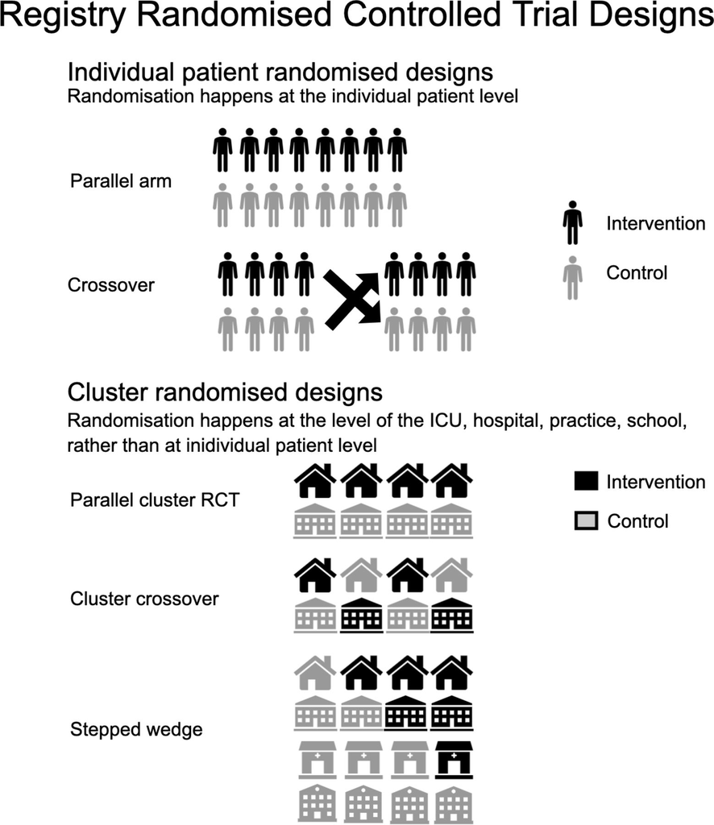

Figure 1: Possible designs for registry randomised controlled trials. ICU, intensive care unit; RCT, randomised controlled trial.  
(image source: https://bmjopen.bmj.com/content/13/3/e068057)

When clustering in the data is ignored in analysis, standard errors of estimates may be artificially reduced, such that there is an increased risk of Type I errors (1–6). Similarly, false positives (Type I error) can result from using degrees of freedom at the level of the individual animal rather than the number of cages in the context of nesting from a cRCT (9). Despite decades of methodological guidance (7,10), clustering and nesting effects are still frequently overlooked in preclinical studies, including those in aging research, and more must be done to account for these effects to achieve valid statistical inference (11).

Fortunately, statistical methods such as linear mixed models, generalized estimating equations, and Cox frailty models provide researchers with robust tools to account for clustering and nesting effects using widely available software packages such as R and SAS (8,12,13). These methods extend standard approaches by modeling dependencies within clusters, ensuring that statistical conclusions accurately reflect the true structure of the data. However, as in other fields, we observe that researchers in the aging field often fail to account for clustering and nesting, underscoring the need for greater statistical rigor.

This tutorial, and our associated paper (14,15), illustrate methods that can be used to account for clustering and nesting using recent data from the Interventions Testing Program (ITP), a multi-site initiative investigating the effects of various compounds on lifespan in genetically heterogeneous UM-HET3 mice, as a case study (16).

Below we demonstrate how both R and SAS can be used to extend classical statistical methods to account for clustering and nesting effects. All examples include relevant code, commented to explain what is being done and why. All code chunks are hidden by default, but can be shown by clicking the “**Show**” button above the table results.

To download the data to run this tutorial, see our OSF site at https://osf.io/rgm2s/overview. Also, see the github repository for this page at https://github.com/BCC-iu/Clustering-and-nesting-tutorial.

Back to top

# Case Study using ITP Survival Data

The 2019 ITP data used in this analysis was generated from an experiment testing the effects of multiple compounds on lifespan in UM-HET3 mice housed at three test sites: University of Michigan(UM), University of Texas (UT), and the Jackson Laboratory (TJL) (16). Briefly, mice were weaned at 42 days of age and assigned to a cage, after which cages were then randomized using a block design. All cage hold 3-4 mice with the exception of 2 cages which hold 2 mice. All mice within the same cage were given the same treatment (as it was included in their food), and randomization was done separately for male and female animals at each test site. There were 777 total cages spread across the three test sites. The treatments used in this study (in addition to the control group) were Astaxanthin (Asta), Meclizine (Mec), Dimethyl fumarate (DMF), Mycophenolic acid (MPA), 4-Phenylbutyrate (PBA), and SG1002 – a hydrogen sulfide donor. Below we show the number of mice and cages in each site and each treatment. Full information on the mice rearing methods can be found in (16).

First we will load in and clean the data, first in R:

```r
knitr::opts_chunk$set(warning = FALSE, message = FALSE)

library(tidyverse) # for manipulating data
library(kableExtra) # for making general tables
library(gtsummary) # for making model tables
library(table1)
library(lmerTest) # for fitting linear mixed models
library(readxl) # for loading in excel files
library(performance) # for calculating ICC values
library(survival) # for survival analyses
library(survminer) # for KM plots
library(broom) # for tidying model fit statistics
library(broom.mixed) # for tidying linear mixed model stats
library(coxme) # fit cox model with nested random effects
#devtools::install_github('junkka/ehahelper') # to extract model information from coxme model
library(ehahelper) # to extract model information from coxme model
library(emmeans) # for getting estimated marginal means
library(patchwork) # package for putting plots together
library(SASmarkdown) # for running SAS code in chunks

# set up the options so that knit knows where the SAS executable is
saspath <- "C:/Program Files/SASHome/SASFoundation/9.4/sas.exe"


ITP.data <- read_xlsx("../Data/C2019 raw with cage numbers 2023-07-24.xlsx") %>%
  mutate(Site = factor(Site),
         Cage = factor(Cage),
         Sex = factor(Sex),
         Rx = factor(Rx,
                     levels = c("Cont_19",
                                "Asta",
                                "DMF_16",
                                "DMF_early",
                                "MEC",
                                "MPA",
                                "PBA",
                                "SG1002_2"))) %>%
  unite(col = "Cage_site", c("Cage", "Site"), remove = FALSE)
# read in the data and set factor variables
# as of 2023-09-22 I'm adding a new variable, Cage_site, which is a combination of cage and site. Doing this because Rich Miller emailed that cages are repeated across different sites.
# also I am now reordering the drug variable now that we have more information about what the different drugs are. Control is Cont_19 and is now the reference level.

ITP.data.long <- ITP.data %>%
    group_by(UMN) %>% # group by animal
    complete(Age = seq(1, max(Age))) %>% # add in rows for all days alive for each animal
    fill(Cage_site, Rx, Sex, Dead, .direction = "updown") %>% # fill in the covariate info
    select(UMN, Age, Cage_site, Sex, Rx, Dead) %>% # select just the few variables I want
  ungroup() %>% # remove ID grouping
  group_by(Cage_site, Age) %>% # group by age and cage, will let us calculate the number of animals alive at each day, per cage
  mutate(num_cagemates_alive = length(unique(UMN)) - 1,
         num_cagemates_alive = factor(num_cagemates_alive,
                                      levels = c("0", "1", "2", "3"))) %>% # add a new variable for number of cagemates alive at each day, changes over time as animals die
  ungroup() %>%
  group_by(UMN) %>% # group by animal again
  mutate(mort = ifelse(Age == max(Age) & Dead == 1, 1, 0)) # make a new variable "mort" which is 1 if a mouse dies on a given day and 0 otherwise. This will be the outcome for the time varying models
# make a "long" form of the data that has one row for each day alive for each mouse. This will be used in plotting and for models


ITP.data.cox <- ITP.data.long %>% # take the long data
  group_by(UMN) %>%
    mutate(stop = max(Age)) %>% # new variable that Surv() function looks for, "stop" which specifies the last age recorded for each animal
  ungroup() %>%
  group_by(UMN, num_cagemates_alive) %>% # group by subject and the number of cagemates alive
  slice_head() %>% # take one row per animal, per number of cagemates alive. This will slice the data at the timepoint/age when the number of cagemates alive changes.
  ungroup() %>%
  mutate(start = 0) %>% # add a new variable "start" for each animal which specifies that each animal started at age/time 0.
  arrange(UMN, Age) %>% # arrange the data so age is ascending within animal
  group_by(UMN) %>% # group by animal
  mutate(tstart = ifelse(Age == 1, Age - 1, Age), # interval start time either 0 (Age - 1) if it's the first interval, or the time of the interval start
         tstop = lead(Age), # interval stop time is the NEXT row's time.
         tstop = ifelse(is.na(tstop), stop, tstop), # make new variables that Surv() looks for. These are the start and stop time for each interval, with the intervals defined by if the number of cagemates alive changes
         mort = ifelse(tstop == stop & Dead == 1, 1, 0)) %>% # update the "mort", endpoint variable to be 1 if the animal died at the end of the given interval. 0 if they didn't
  filter(!c(tstart == tstop & mort == 1)) # remove rows created in error where the start and stop time of the interval were the same days, and the animal was already recorded as dead.
# make the time varying cox model dataset

ITP.data.lmm <- ITP.data.cox %>%
  group_by(UMN) %>%
  mutate(Age.at.change = ifelse(mort == 1, tstop, lead(Age))) %>%
  filter(Dead == 1)
# make a different dataset specific to the time varying covariate cox model with time varying covariates, this one will use Age.at.change as the outcome where that age can either be the time of death, or the time at which the number of cagemates changes.
```

Then in SAS:

```sas
%let filepath=C:\ITP cages\Data;

data _null_;

   today = put(date(), YYMMDDD10.);*this returns the date in the format 2022-09-08;

   call symput('today',today);

run;*use in code as &today.;

%put &today.;

/*************************************************** Read in Dataset ***************************************************/

PROC IMPORT OUT= WORK.ITP_data

           DATAFILE= "&filepath.\C2019 raw with cage numbers 2023-07-24.xlsx"

            DBMS=EXCEL REPLACE;

    RANGE="UM C2019 LT 10-12-22$";

     GETNAMES=YES;

     MIXED=NO;

     SCANTEXT=YES;

     USEDATE=YES;

     SCANTIME=YES;

RUN;

/* make a new Cage_site variable for clustering, and then filter the data to include just the non-censored animals, like the paper did */

data WORK.ITP_data;

    set WORK.ITP_data;

    Cage_site = Cage || Site;

   drop F11 F12 F13 F14 F15 F16 F17 F18 F19 F20 F21 F22 F23 F24 F25 F26 F27 F28 F29 F30 F31 F32 F33 F34 ;

run;

data WORK.ITP_filtered_data;

   set WORK.ITP_data;

   IF Dead = 1 THEN OUTPUT;

run;
```

Now we can look at some descriptive tables of the sample, using R code:

```r
my.render.cat <- function(x) {
    c("", sapply(stats.default(x), function(y) with(y,
        sprintf("%d", FREQ))))
}
label(ITP.data$Rx) <- "Treatment"

cell_mice <- as.data.frame(table1(~Rx|Site, data=ITP.data, render.categorical=my.render.cat, overall = F) )
cell_cage <- as.data.frame(table1(~Rx|Site, data=ITP.data |> group_by(Cage_site) |> filter(row_number()==1) |> ungroup(), render.categorical=my.render.cat, overall = F))
cell_mice_cage <- as.data.frame(mapply(function(x, y) paste0(x, " (", y, ")"), cell_mice, cell_cage)) |>
  filter(!row_number()%in%c(1,2))
cell_mice_cage[,1] <- cell_mice[3:10,1]
cell_mice_cage |>
  kable(caption="<center>Number of Animals (Cages) in each Treatment x Site</center>", align="c") %>%
  kable_styling(full_width = T)
```

Number of Animals (Cages) in each Treatment x Site

|  | TJL | UM | UT |
| --- | --- | --- | --- |
| Cont_19 | 208 (61) | 193 (57) | 194 (57) |
| Asta | 102 (30) | 95 (28) | 95 (28) |
| DMF_16 | 102 (30) | 95 (28) | 95 (28) |
| DMF_early | 102 (30) | 94 (28) | 95 (28) |
| MEC | 102 (30) | 94 (28) | 95 (28) |
| MPA | 102 (30) | 95 (28) | 95 (28) |
| PBA | 102 (30) | 94 (28) | 95 (28) |
| SG1002_2 | 102 (30) | 94 (28) | 95 (28) |

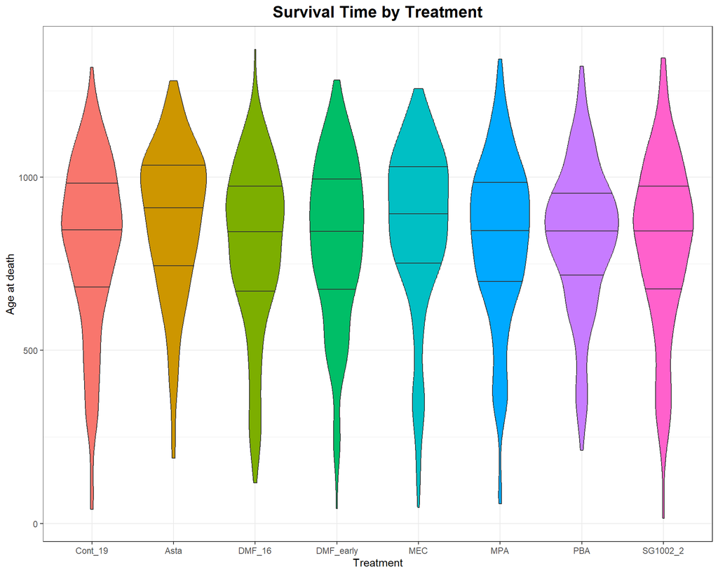

```r
# make a violin plot of the distribution of survival times by treatment
ggplot(ITP.data, aes(x = Rx, y = Age, fill = Rx)) + # use ggplot to plot treatment on the x-axis, age on the y, and color by treatment
  geom_violin(draw_quantiles = c(0.25, 0.5, 0.75)) + # draw a violin plot with the defined quantiles
  labs( title = "Survival Time by Treatment",
        x = "Treatment",
        y = "Age at death") + # change the labels
  theme_bw() + # use a simple black and white theme
  theme(legend.position="none") + # remove the legend as it is redundant
  theme(plot.title = element_text(hjust = 0.5, size = 16, face = "bold")) +
  scale_color_manual(values=rainbow(length(unique(ITP.data$Rx)), s = .8, v = .9)[sample(1:length(unique(ITP.data$Rx)), length(unique(ITP.data$Rx)))]) # set my own colors that are easily idetifiable and unique
```

Back to top

# Descriptive Statistics

As a first starting point when working with data, we generally want to look at some basic descriptive statistics. We have descriptive statistics for survival time by treatment, sex, and site - along with exploratory plots of survival time by treatment.

**Descriptive statistics of survival time**

Three tables of mean, median, IQR, max, and min of survival time by Rx, site, and sex combinations.

```r
# below to make tables for descriptive data

ITP.data %>% # take the dataset
    select(Rx, Sex, Age) %>% # select just the treatment, sex and age variables
    tbl_strata( # make a stratified table
        strata = Sex, # that is stratified by sex
        ~.x %>%
            tbl_summary( # within each sex strata, make a summary table
                by = Rx, # that is further stratified by treatment
                statistic = list(Age ~ "{mean};  {median};  ({p25}, {p75});  ({min}, {max})") # report this list of statistics
            ),
        modify_header(all_stat_cols() ~ "**{level}**"), # label each table strata with the level of the "by =" variable level
        .header = "**{strata}**, N = {n}" # then label the top level strata by the "strata =" variable level
    )
```

| **Characteristic** | **F**, N = 1234 **Cont_19** N = 284<sup>1</sup> | **F**, N = 1234 **Asta** N = 136<sup>1</sup> | **F**, N = 1234 **DMF_16** N = 136<sup>1</sup> | **F**, N = 1234 **DMF_early** N = 135<sup>1</sup> | **F**, N = 1234 **MEC** N = 136<sup>1</sup> | **F**, N = 1234 **MPA** N = 136<sup>1</sup> | **F**, N = 1234 **PBA** N = 136<sup>1</sup> | **F**, N = 1234 **SG1002_2** N = 135<sup>1</sup> | **M**, N = 1401 **Cont_19** N = 311<sup>1</sup> | **M**, N = 1401 **Asta** N = 156<sup>1</sup> | **M**, N = 1401 **DMF_16** N = 156<sup>1</sup> | **M**, N = 1401 **DMF_early** N = 156<sup>1</sup> | **M**, N = 1401 **MEC** N = 155<sup>1</sup> | **M**, N = 1401 **MPA** N = 156<sup>1</sup> | **M**, N = 1401 **PBA** N = 155<sup>1</sup> | **M**, N = 1401 **SG1002_2** N = 156<sup>1</sup> |
| --- | --- | --- | --- | --- | --- | --- | --- | --- | --- | --- | --- | --- | --- | --- | --- | --- |
| Age | 878; 889; (771, 1,017); (41, 1,306) | 896; 920; (804, 1,035); (403, 1,219) | 859; 885; (757, 975); (117, 1,369) | 857; 896; (726, 998); (169, 1,227) | 897; 917; (801, 1,044); (170, 1,204) | 857; 880; (746, 967); (388, 1,276) | 857; 878; (760, 953); (467, 1,159) | 858; 871; (765, 1,005); (15, 1,253) | 748; 792; (537, 953); (42, 1,318) | 857; 908; (704, 1,040); (188, 1,279) | 752; 778; (575, 974); (182, 1,258) | 787; 814; (602, 991); (43, 1,281) | 815; 864; (694, 1,019); (46, 1,256) | 790; 808; (632, 1,000); (57, 1,341) | 799; 832; (634, 960); (211, 1,321) | 758; 784; (556, 942); (189, 1,345) |

<sup>1</sup> Mean; Median; (Q1, Q3); (Min, Max)

```r
# then do the same thing with a different set of strata variables
ITP.data %>%
    select(Site, Sex, Age) %>%
    tbl_strata(
        strata = Sex,
        ~.x %>%
            tbl_summary(
                by = Site,
                statistic = list(Age ~ "{mean};  {median};  ({p25}, {p75});  ({min}, {max})")
            ),
        modify_header(all_stat_cols() ~ "**{level}**"),
        .header = "**{strata}**, N = {n}"
    )
```

| **Characteristic** | **F**, N = 1234 **TJL** N = 436<sup>1</sup> | **F**, N = 1234 **UM** N = 398<sup>1</sup> | **F**, N = 1234 **UT** N = 400<sup>1</sup> | **M**, N = 1401 **TJL** N = 486<sup>1</sup> | **M**, N = 1401 **UM** N = 456<sup>1</sup> | **M**, N = 1401 **UT** N = 459<sup>1</sup> |
| --- | --- | --- | --- | --- | --- | --- |
| Age | 901; 919; (792, 1,034); (183, 1,369) | 855; 868; (757, 983); (15, 1,204) | 853; 880; (748, 980); (117, 1,223) | 764; 795; (578, 954); (91, 1,322) | 820; 871; (678, 1,026); (42, 1,341) | 769; 809; (566, 967); (211, 1,345) |

<sup>1</sup> Mean; Median; (Q1, Q3); (Min, Max)

```r
ITP.data %>%
    select(Site, Rx, Age) %>%
    tbl_strata(
        strata = Site,
        ~.x %>%
            tbl_summary(
                by = Rx,
                statistic = list(Age ~ "{mean};  {median};  ({p25}, {p75});  ({min}, {max})")
            ),
        modify_header(all_stat_cols() ~ "**{level}**"),
        .header = "**{strata}**, N = {n}"
    )
```

| **Characteristic** | **TJL**, N = 922 **Cont_19** N = 208<sup>1</sup> | **TJL**, N = 922 **Asta** N = 102<sup>1</sup> | **TJL**, N = 922 **DMF_16** N = 102<sup>1</sup> | **TJL**, N = 922 **DMF_early** N = 102<sup>1</sup> | **TJL**, N = 922 **MEC** N = 102<sup>1</sup> | **TJL**, N = 922 **MPA** N = 102<sup>1</sup> | **TJL**, N = 922 **PBA** N = 102<sup>1</sup> | **TJL**, N = 922 **SG1002_2** N = 102<sup>1</sup> | **UM**, N = 854 **Cont_19** N = 193<sup>1</sup> | **UM**, N = 854 **Asta** N = 95<sup>1</sup> | **UM**, N = 854 **DMF_16** N = 95<sup>1</sup> | **UM**, N = 854 **DMF_early** N = 94<sup>1</sup> | **UM**, N = 854 **MEC** N = 94<sup>1</sup> | **UM**, N = 854 **MPA** N = 95<sup>1</sup> | **UM**, N = 854 **PBA** N = 94<sup>1</sup> | **UM**, N = 854 **SG1002_2** N = 94<sup>1</sup> | **UT**, N = 859 **Cont_19** N = 194<sup>1</sup> | **UT**, N = 859 **Asta** N = 95<sup>1</sup> | **UT**, N = 859 **DMF_16** N = 95<sup>1</sup> | **UT**, N = 859 **DMF_early** N = 95<sup>1</sup> | **UT**, N = 859 **MEC** N = 95<sup>1</sup> | **UT**, N = 859 **MPA** N = 95<sup>1</sup> | **UT**, N = 859 **PBA** N = 95<sup>1</sup> | **UT**, N = 859 **SG1002_2** N = 95<sup>1</sup> |
| --- | --- | --- | --- | --- | --- | --- | --- | --- | --- | --- | --- | --- | --- | --- | --- | --- | --- | --- | --- | --- | --- | --- | --- | --- |
| Age | 835; 848; (693, 1,022); (150, 1,306) | 871; 912; (759, 1,035); (188, 1,243) | 796; 809; (648, 975); (182, 1,369) | 807; 826; (677, 969); (262, 1,227) | 865; 911; (773, 1,028); (223, 1,206) | 806; 862; (679, 968); (91, 1,291) | 818; 854; (667, 943); (259, 1,287) | 825; 868; (655, 1,001); (234, 1,322) | 796; 865; (698, 982); (41, 1,318) | 905; 946; (752, 1,056); (202, 1,279) | 809; 852; (722, 947); (239, 1,157) | 822; 880; (673, 1,007); (43, 1,243) | 885; 910; (768, 1,058); (46, 1,256) | 850; 836; (699, 1,005); (57, 1,341) | 859; 859; (749, 1,006); (324, 1,321) | 805; 851; (710, 950); (15, 1,292) | 797; 839; (637, 961); (231, 1,241) | 851; 885; (678, 997); (298, 1,226) | 801; 841; (667, 998); (117, 1,258) | 829; 845; (669, 1,025); (228, 1,281) | 809; 864; (682, 991); (170, 1,171) | 808; 858; (690, 971); (326, 1,278) | 801; 835; (694, 954); (211, 1,215) | 780; 796; (666, 946); (193, 1,345) |

<sup>1</sup> Mean; Median; (Q1, Q3); (Min, Max)

Back to top

# Intra-Class Correlation

Because we are dealing with nested/clustered data, we are also presenting calculations of Intraclass correlation (ICC) values for both cage and site clusters. From these ICC values, we can see that if we only account for the similarity between sites, we are missing ~10% of the variation that can be explained just from the cages, or cages within sites. Because of this, we know that it is important to properly account for both cages and sites within our modeling framework.

**ICC by cage and site**

```r
ITP.data.dead <- ITP.data %>%
  filter(Dead == 1)

mod.cage <- lmer(Age ~ 1 + (1 | Cage_site), data = ITP.data.dead)
# fit a intercept only model on the outcome (Age at death) which includes a random intercept for cage.

ICC.cage <- performance::icc(mod.cage)
# return the ICC for cage, this gives the same value as manually doing Variance between / (Variance between + Variance within) like so:
# print(VarCorr(mod.site), comp = "Variance") to get the variances and 6816 / (6816 + 49176) to calculate it.


mod.site <- lmer(Age ~ 1 + (1 | Site), data = ITP.data.dead)
# fit a intercept only model on the outcome (Age at death) which includes a random intercept for site

ICC.site <- performance::icc(mod.site)
# return the ICC for site

mod.site.cage <- lmer(Age ~ 1 + (1 | Site / Cage_site), data = ITP.data.dead)
# fit a intercept only model on the outcome (Age at death) which includes a random intercept for site

ICC.site.cage <- performance::icc(mod.site.cage)
# return the ICC for site by cage clustering

# put it all together into a data frame
data.frame("Clustering variable" = c("Cage", "Site", "Site by cage"),
           "Average per cluster" = c(round(ITP.data.dead %>% group_by(Cage_site) %>% mutate(count = n()) %>% slice_head() %>% ungroup() %>% summarise("mean mice per Cage" = mean(count)) %>% as.numeric(), 2),
                                     round(ITP.data.dead %>% group_by(Site) %>% mutate(count = n()) %>% slice_head() %>% ungroup() %>% summarise("mean mice per Site" = mean(count)) %>% as.numeric(),2),
                                     round(ITP.data.dead %>% group_by(Site, Cage_site) %>% mutate(count = n()) %>% slice_head() %>% ungroup() %>% summarise("mean mice per Site per cage" = mean(count)) %>% as.numeric(),2)),
           ICC = c(round(ICC.cage$ICC_unadjusted, 3),
                   round(ICC.site$ICC_unadjusted,3),
                   round(ICC.site.cage$ICC_unadjusted,3))) %>%
  kable(col.names = c("Clustering variable", "Average per cluster", "ICC"),
        caption="<center>Overall ICC for all samples</center>", align="l") %>%
  kable_styling(full_width = T)
```

Overall ICC for all samples

| Clustering variable | Average per cluster | ICC |
| --- | --- | --- |
| Cage | 3.38 | 0.122 |
| Site | 856.33 | 0.011 |
| Site by cage | 3.38 | 0.126 |

```r
ITP.data.male <- ITP.data.dead %>%
  filter(Sex == "M")

mod.cage <- lmer(Age ~ 1 + (1 | Cage_site), data = ITP.data.male)
# fit a intercept only model on the outcome (Age at death) which includes a random intercept for cage.

ICC.cage <- performance::icc(mod.cage)
# return the ICC for cage, this gives the same value as manually doing Variance between / (Variance between + Variance within) like so:
# print(VarCorr(mod.site), comp = "Variance") to get the variances and 6816 / (6816 + 49176) to calculate it.


mod.site <- lmer(Age ~ 1 + (1 | Site), data = ITP.data.male)
# fit a intercept only model on the outcome (Age at death) which includes a random intercept for site

ICC.site <- performance::icc(mod.site)
# return the ICC for site

mod.site.cage <- lmer(Age ~ 1 + (1 | Site / Cage_site), data = ITP.data.male)
# fit a intercept only model on the outcome (Age at death) which includes a random intercept for site

ICC.site.cage <- performance::icc(mod.site.cage)
# return the ICC for site by cage clustering

# put it all together into a data frame
data.frame("Clustering variable" = c("Cage", "Site", "Site by cage"),
           "Average per cluster" = c(round(ITP.data.male %>% group_by(Cage_site) %>% mutate(count = n()) %>% slice_head() %>% ungroup() %>% summarise("mean mice per Cage" = mean(count)) %>% as.numeric(), 2),
                                     round(ITP.data.male %>% group_by(Site) %>% mutate(count = n()) %>% slice_head() %>% ungroup() %>% summarise("mean mice per Site" = mean(count)) %>% as.numeric(),2),
                                     round(ITP.data.male %>% group_by(Site, Cage_site) %>% mutate(count = n()) %>% slice_head() %>% ungroup() %>% summarise("mean mice per Site per cage" = mean(count)) %>% as.numeric(),2)),
           ICC = c(round(ICC.cage$ICC_unadjusted, 3),
                   round(ICC.site$ICC_unadjusted,3),
                   round(ICC.site.cage$ICC_unadjusted,3))) %>%
  kable(col.names = c("Clustering variable", "Average per cluster", "ICC"),
        caption="<center>Overall ICC for males</center>", align="l") %>%
  kable_styling(full_width = T)
```

Overall ICC for males

| Clustering variable | Average per cluster | ICC |
| --- | --- | --- |
| Cage | 2.98 | 0.090 |
| Site | 449.33 | 0.031 |
| Site by cage | 2.98 | 0.099 |

```r
ITP.data.female <- ITP.data.dead %>%
  filter(Sex == "F")

mod.cage <- lmer(Age ~ 1 + (1 | Cage_site), data = ITP.data.female)
# fit a intercept only model on the outcome (Age at death) which includes a random intercept for cage.

ICC.cage <- performance::icc(mod.cage)
# return the ICC for cage, this gives the same value as manually doing Variance between / (Variance between + Variance within) like so:
# print(VarCorr(mod.site), comp = "Variance") to get the variances and 6816 / (6816 + 49176) to calculate it.


mod.site <- lmer(Age ~ 1 + (1 | Site), data = ITP.data.female)
# fit a intercept only model on the outcome (Age at death) which includes a random intercept for site

ICC.site <- performance::icc(mod.site)
# return the ICC for site

mod.site.cage <- lmer(Age ~ 1 + (1 | Site / Cage_site), data = ITP.data.female)
# fit a intercept only model on the outcome (Age at death) which includes a random intercept for site

ICC.site.cage <- performance::icc(mod.site.cage)
# return the ICC for site by cage clustering

# put it all together into a data frame
data.frame("Clustering variable" = c("Cage", "Site", "Site by cage"),
           "Average per cluster" = c(round(ITP.data.female %>% group_by(Cage_site) %>% mutate(count = n()) %>% slice_head() %>% ungroup() %>% summarise("mean mice per Cage" = mean(count)) %>% as.numeric(), 2),
                                     round(ITP.data.female %>% group_by(Site) %>% mutate(count = n()) %>% slice_head() %>% ungroup() %>% summarise("mean mice per Site" = mean(count)) %>% as.numeric(),2),
                                     round(ITP.data.female %>% group_by(Site, Cage_site) %>% mutate(count = n()) %>% slice_head() %>% ungroup() %>% summarise("mean mice per Site per cage" = mean(count)) %>% as.numeric(),2)),
           ICC = c(round(ICC.cage$ICC_unadjusted, 3),
                   round(ICC.site$ICC_unadjusted,3),
                   round(ICC.site.cage$ICC_unadjusted,3))) %>%
  kable(col.names = c("Clustering variable", "Average per cluster", "ICC"),
        caption="<center>Overall ICC for females</center>", align="l") %>%
  kable_styling(full_width = T)
```

Overall ICC for females

| Clustering variable | Average per cluster | ICC |
| --- | --- | --- |
| Cage | 3.96 | 0.093 |
| Site | 407.00 | 0.017 |
| Site by cage | 3.96 | 0.097 |

Back to top

# Linear Mixed Models

We fit linear models as a baseline where the number of days alive was treated as a continuous outcome on only the non-censored animals. To assess the impact of cage clustering effects, we fit linear mixed models, with random intercepts for cage nested within treatment where the number of days alive was treated as a continuous outcome for all non-censored animals. Cage nested within treatment was included as a random intercept to capture the degree to which animals housed in the same cage might have survival times more similar to each other than to animals housed in some other cage, due to “random”, unmeasured factors that are not accounted for in the model. Denominator degrees of freedom were adjusted using the Kenward-Roger approximation to be at the level of the number of cages rather than individual animals. Statistical significance of the interaction term and main effects were assessed using type 3 sum of squares, and estimated marginal means were compared to assess significant differences in lifespan between each treatment group and the control group within each sex.

Below we have results from linear models which do not account for cage and site nesting and clustering effects, and linear mixed models which do account for these effects using the Kenward-Roger degrees of freedom approximation. These results are presented using both R and SAS code.

### Fitted Models

Below we see results of R and SAS. For both the R and SAS code sections we first see the results for the linear models (not accounting for cage and site effects), and then for the linear mixed models which do properly account for cage and site.

**R results**

We use the `lmer()` function from the `lmerTest` package in R to fit the linear mixed model. The model `lmer(Age ~ Rx * Sex + (1 | Cage_site : Rx) + (1 | Site)` adjusts for the *clustering* effects of cage and the *nesting* effect of treatment and sites. Comparing the results from `summary()` in linear model and linear mixed models, the standard errors of the coefficients have increased when the clustering and nesting have been accounted and hence Type I error rate is reduced.

First we fit a linear model which does not adjust for the cage clusters, or the fact that treatment is nested within sites. Then, we look at the results of that model using the `summary()` command.

```r
# fit linear model
lm.noclus <- lm(Age ~ Rx * Sex, data = ITP.data.no.cen)
summary(lm.noclus)
```

```
Call:
lm(formula = Age ~ Rx * Sex, data = ITP.data.no.cen)

Residuals:
    Min      1Q  Median      3Q     Max
-769.05 -127.75   21.96  150.82  570.02

Coefficients:
            Estimate Std. Error t value Pr(>|t|)
(Intercept)  840.711      4.434 189.625  < 2e-16 ***
Rx1          -13.809      9.019  -1.531 0.125865
Rx2           39.954     12.019   3.324 0.000899 ***
Rx3          -23.553     12.065  -1.952 0.051026 .
Rx4           -4.327     12.089  -0.358 0.720413
Rx5           29.547     12.065   2.449 0.014390 *
Rx6           -3.596     12.109  -0.297 0.766507
Rx7           -6.292     12.035  -0.523 0.601178
Sex1          32.820      4.434   7.403  1.8e-13 ***
Rx1:Sex1      21.332      9.019   2.365 0.018095 *
Rx2:Sex1      -9.302     12.019  -0.774 0.439017
Rx3:Sex1       8.684     12.065   0.720 0.471741
Rx4:Sex1     -10.107     12.089  -0.836 0.403206
Rx5:Sex1      -6.041     12.065  -0.501 0.616614
Rx6:Sex1      -9.543     12.109  -0.788 0.430700
Rx7:Sex1     -10.009     12.035  -0.832 0.405671
---
Signif. codes:  0 '***' 0.001 '**' 0.01 '*' 0.05 '.' 0.1 ' ' 1

Residual standard error: 218.2 on 2553 degrees of freedom
Multiple R-squared:  0.03745,   Adjusted R-squared:  0.0318
F-statistic: 6.623 on 15 and 2553 DF,  p-value: 3.55e-14
```

Then we fit the linear mixed model by loading the `lmerTest` package and using the `lmer()` function from said package. Here we are using `lmerTest` instead of the alternative, `lmer` package as it provides p-values by default in the `summary()` results table. As before, we are fitting the model and then examining the results.

```r
library(lmerTest) # first load the lmerTest package for fitting the mixed models, using the lmer command
# fit the mixed model
lmm.cage <- lmer(Age ~ Rx * Sex + (1 | Cage_site : Rx) + (1 | Site), data = ITP.data.no.cen)
summary(lmm.cage)
```

```
Linear mixed model fit by REML. t-tests use Satterthwaite's method [
lmerModLmerTest]
Formula: Age ~ Rx * Sex + (1 | Cage_site:Rx) + (1 | Site)
   Data: ITP.data.no.cen

REML criterion at convergence: 34809.8

Scaled residuals:
    Min      1Q  Median      3Q     Max
-3.4315 -0.5769  0.0834  0.6627  2.4965

Random effects:
 Groups       Name        Variance Std.Dev.
 Cage_site:Rx (Intercept)  4081.6   63.89
 Site         (Intercept)   514.6   22.69
 Residual                 43290.2  208.06
Number of obs: 2569, groups:  Cage_site:Rx, 761; Site, 3

Fixed effects:
            Estimate Std. Error      df t value Pr(>|t|)
(Intercept)  840.825     13.977   2.020  60.158 0.000258 ***
Rx1          -13.590      9.918 661.558  -1.370 0.171083
Rx2           39.434     13.238 648.837   2.979 0.003001 **
Rx3          -23.792     13.276 656.141  -1.792 0.073578 .
Rx4           -4.167     13.295 661.174  -0.313 0.754042
Rx5           29.684     13.274 657.657   2.236 0.025666 *
Rx6           -3.646     13.313 664.195  -0.274 0.784246
Rx7           -6.186     13.239 659.200  -0.467 0.640499
Sex1          32.630      4.878 658.540   6.689  4.8e-11 ***
Rx1:Sex1      21.406      9.918 661.565   2.158 0.031271 *
Rx2:Sex1      -9.468     13.237 648.795  -0.715 0.474701
Rx3:Sex1       8.923     13.276 656.115   0.672 0.501743
Rx4:Sex1     -10.418     13.295 661.182  -0.784 0.433531
Rx5:Sex1      -6.178     13.274 657.678  -0.465 0.641762
Rx6:Sex1      -9.384     13.313 664.250  -0.705 0.481132
Rx7:Sex1      -9.961     13.239 659.210  -0.752 0.452109
---
Signif. codes:  0 '***' 0.001 '**' 0.01 '*' 0.05 '.' 0.1 ' ' 1
```

**SAS results**

In SAS we use the PROC MIXED command to fit the linear and linear mixed models. When we fit the linear models the `random` statement is omitted, but is included when we fit the linear mixed model. Note that just like in the R code we are choosing to use the Kenward-Roger’s degrees of freedom approximation.

Note here that the default SAS output contains different pieces of information as compared to the default R output from the `summary()` command. Both have beta estimates, standard errors, and p-values for each term. But, the SAS output additionally also contains estimated degrees of freedom for each term in the fixed effect table, along with additional tables for the structure of the model - and the table of type 3 F-test results which we will focus on in the next section.

```
/* below to fit the standard linear model which is the equivalent of the R linear model fit before  */

PROC MIXED data = ITP_filtered_data;

   class Rx(ref="Cont_19") Sex Cage_site;

   model Age = Rx Sex Rx * Sex / solution ;

RUN;
```

| Model Information |  |
| --- | --- |
| Data Set | WORK.ITP_FILTERED_DATA |
| Dependent Variable | Age |
| Covariance Structure | Diagonal |
| Estimation Method | REML |
| Residual Variance Method | Profile |
| Fixed Effects SE Method | Model-Based |
| Degrees of Freedom Method | Residual |

| Class Level Information Class | Class Level Information Levels | Class Level Information Values |
| --- | --- | --- |
| Rx | 8 | Asta DMF_16 DMF_early MEC MPA PBA SG1002_2 Cont_19 |
| Sex | 2 | F M |
| Cage_site | 761 | 3300TJL 3301TJL 3302TJL 3303TJL 3304TJL 3305TJL 3306TJL 3307TJL 3308TJL 3309TJL 3310TJL 3311TJL 3312TJL 3313TJL 3314TJL 3315TJL 3316TJL 3317TJL 3318TJL 3319TJL 3320TJL 3321TJL 3322TJL 3323TJL 3324TJL … |

| Dimensions |  |
| --- | --- |
| Covariance Parameters | 1 |
| Columns in X | 27 |
| Columns in Z | 0 |
| Subjects | 1 |
| Max Obs per Subject | 2569 |

| Number of Observations |  |
| --- | --- |
| Number of Observations Read | 2569 |
| Number of Observations Used | 2569 |
| Number of Observations Not Used | 0 |

| Covariance Parameter Estimates Cov Parm | Covariance Parameter Estimates Estimate |
| --- | --- |
| Residual | 47589 |

| Fit Statistics |  |
| --- | --- |
| -2 Res Log Likelihood | 34822.6 |
| AIC (Smaller is Better) | 34824.6 |
| AICC (Smaller is Better) | 34824.6 |
| BIC (Smaller is Better) | 34830.4 |

| Solution for Fixed Effects Effect | Solution for Fixed Effects Rx | Solution for Fixed Effects Sex | Solution for Fixed Effects Estimate | Solution for Fixed Effects Standard Error | Solution for Fixed Effects DF | Solution for Fixed Effects t Value | Solution for Fixed Effects Pr > \|t\| |
| --- | --- | --- | --- | --- | --- | --- | --- |
| Intercept |  |  | 772.75 | 12.6584 | 2553 | 61.05 | <.0001 |
| Rx | Asta |  | 84.3966 | 21.5707 | 2553 | 3.91 | <.0001 |
| Rx | DMF_16 |  | 2.9046 | 21.9496 | 2553 | 0.13 | 0.8947 |
| Rx | DMF_early |  | 40.9203 | 21.9004 | 2553 | 1.87 | 0.0618 |
| Rx | MEC |  | 70.7289 | 21.9496 | 2553 | 3.22 | 0.0013 |
| Rx | MPA |  | 41.0881 | 21.9004 | 2553 | 1.88 | 0.0608 |
| Rx | PBA |  | 38.8584 | 21.8036 | 2553 | 1.78 | 0.0748 |
| Rx | SG1002_2 |  | 2.2292 | 21.8517 | 2553 | 0.10 | 0.9188 |
| Rx | Cont_19 |  | 0 | . | . | . | . |
| Sex |  | F | 108.30 | 18.1381 | 2553 | 5.97 | <.0001 |
| Sex |  | M | 0 | . | . | . | . |
| Rx*Sex | Asta | F | -61.2680 | 31.5369 | 2553 | -1.94 | 0.0522 |
| Rx*Sex | Asta | M | 0 | . | . | . | . |
| Rx*Sex | DMF_16 | F | -25.2960 | 31.6301 | 2553 | -0.80 | 0.4239 |
| Rx*Sex | DMF_16 | M | 0 | . | . | . | . |
| Rx*Sex | DMF_early | F | -62.8765 | 31.6785 | 2553 | -1.98 | 0.0473 |
| Rx*Sex | DMF_early | M | 0 | . | . | . | . |
| Rx*Sex | MEC | F | -54.7453 | 31.6301 | 2553 | -1.73 | 0.0836 |
| Rx*Sex | MEC | M | 0 | . | . | . | . |
| Rx*Sex | MPA | F | -61.7503 | 31.7206 | 2553 | -1.95 | 0.0517 |
| Rx*Sex | MPA | M | 0 | . | . | . | . |
| Rx*Sex | PBA | F | -62.6820 | 31.5700 | 2553 | -1.99 | 0.0472 |
| Rx*Sex | PBA | M | 0 | . | . | . | . |
| Rx*Sex | SG1002_2 | F | -12.6884 | 31.6871 | 2553 | -0.40 | 0.6889 |
| Rx*Sex | SG1002_2 | M | 0 | . | . | . | . |
| Rx*Sex | Cont_19 | F | 0 | . | . | . | . |
| Rx*Sex | Cont_19 | M | 0 | . | . | . | . |

| Type 3 Tests of Fixed Effects Effect | Type 3 Tests of Fixed Effects Num DF | Type 3 Tests of Fixed Effects Den DF | Type 3 Tests of Fixed Effects F Value | Type 3 Tests of Fixed Effects Pr > F |
| --- | --- | --- | --- | --- |
| Rx | 7 | 2553 | 3.23 | 0.0020 |
| Sex | 1 | 2553 | 54.80 | <.0001 |
| Rx*Sex | 7 | 2553 | 1.35 | 0.2211 |

```
/* below to fit the linear mixed model which is the equivalent of the R mixed model fit before, here also using Kenward-Roger DF approximation  */

PROC MIXED data = ITP_filtered_data covtest;

   class Rx(ref="Cont_19") Sex Site Cage_site;

   model Age = Rx Sex Rx * Sex / solution DDFM = KENWARDROGER;

   random intercept / subject=Cage_site(Rx) ;*type = un;

   random intercept / subject=Site ;*type = un;

RUN;
```

| Model Information |  |
| --- | --- |
| Data Set | WORK.ITP_FILTERED_DATA |
| Dependent Variable | Age |
| Covariance Structure | Variance Components |
| Subject Effects | Cage_site(Rx), Site |
| Estimation Method | REML |
| Residual Variance Method | Profile |
| Fixed Effects SE Method | Kenward-Roger |
| Degrees of Freedom Method | Kenward-Roger |

| Class Level Information Class | Class Level Information Levels | Class Level Information Values |
| --- | --- | --- |
| Rx | 8 | Asta DMF_16 DMF_early MEC MPA PBA SG1002_2 Cont_19 |
| Sex | 2 | F M |
| Site | 3 | TJL UM UT |
| Cage_site | 761 | 3300TJL 3301TJL 3302TJL 3303TJL 3304TJL 3305TJL 3306TJL 3307TJL 3308TJL 3309TJL 3310TJL 3311TJL 3312TJL 3313TJL 3314TJL 3315TJL 3316TJL 3317TJL 3318TJL 3319TJL 3320TJL 3321TJL 3322TJL 3323TJL 3324TJL … |

| Dimensions |  |
| --- | --- |
| Covariance Parameters | 3 |
| Columns in X | 27 |
| Columns in Z per Subject | 764 |
| Subjects | 1 |
| Max Obs per Subject | 2569 |

| Number of Observations |  |
| --- | --- |
| Number of Observations Read | 2569 |
| Number of Observations Used | 2569 |
| Number of Observations Not Used | 0 |

| Iteration History Iteration | Iteration History Evaluations | Iteration History -2 Res Log Like | Iteration History Criterion |
| --- | --- | --- | --- |
| 0 | 1 | 34822.55379458 |  |
| 1 | 2 | 34790.38864462 | 0.00000007 |
| 2 | 1 | 34790.38752633 | 0.00000000 |

| Convergence criteria met. |
| --- |

| Covariance Parameter Estimates Cov Parm | Covariance Parameter Estimates Subject | Covariance Parameter Estimates Estimate | Covariance Parameter Estimates Standard Error | Covariance Parameter Estimates Z Value | Covariance Parameter Estimates Pr > Z |
| --- | --- | --- | --- | --- | --- |
| Intercept | Cage_site(Rx) | 4081.54 | 1017.23 | 4.01 | <.0001 |
| Intercept | Site | 514.41 | 582.67 | 0.88 | 0.1887 |
| Residual |  | 43290 | 1456.22 | 29.73 | <.0001 |

| Fit Statistics |  |
| --- | --- |
| -2 Res Log Likelihood | 34790.4 |
| AIC (Smaller is Better) | 34796.4 |
| AICC (Smaller is Better) | 34796.4 |
| BIC (Smaller is Better) | 34790.4 |

| Solution for Fixed Effects Effect | Solution for Fixed Effects Rx | Solution for Fixed Effects Sex | Solution for Fixed Effects Estimate | Solution for Fixed Effects Standard Error | Solution for Fixed Effects DF | Solution for Fixed Effects t Value | Solution for Fixed Effects Pr > \|t\| |
| --- | --- | --- | --- | --- | --- | --- | --- |
| Intercept |  |  | 773.20 | 18.9266 | 6.79 | 40.85 | <.0001 |
| Rx | Asta |  | 83.8986 | 23.2959 | 840 | 3.60 | 0.0003 |
| Rx | DMF_16 |  | 2.2805 | 23.6970 | 846 | 0.10 | 0.9234 |
| Rx | DMF_early |  | 41.2472 | 23.6438 | 845 | 1.74 | 0.0814 |
| Rx | MEC |  | 70.8584 | 23.6885 | 849 | 2.99 | 0.0029 |
| Rx | MPA |  | 40.7340 | 23.6459 | 845 | 1.72 | 0.0853 |
| Rx | PBA |  | 38.7711 | 23.5310 | 849 | 1.65 | 0.0998 |
| Rx | SG1002_2 |  | 2.1795 | 23.5996 | 840 | 0.09 | 0.9264 |
| Rx | Cont_19 |  | 0 | . | . | . | . |
| Sex |  | F | 108.07 | 19.9443 | 663 | 5.42 | <.0001 |
| Sex |  | M | 0 | . | . | . | . |
| Rx*Sex | Asta | F | -61.7481 | 34.7195 | 652 | -1.78 | 0.0758 |
| Rx*Sex | Asta | M | 0 | . | . | . | . |
| Rx*Sex | DMF_16 | F | -24.9655 | 34.7991 | 658 | -0.72 | 0.4734 |
| Rx*Sex | DMF_16 | M | 0 | . | . | . | . |
| Rx*Sex | DMF_early | F | -63.6482 | 34.8363 | 662 | -1.83 | 0.0681 |
| Rx*Sex | DMF_early | M | 0 | . | . | . | . |
| Rx*Sex | MEC | F | -55.1684 | 34.7934 | 659 | -1.59 | 0.1133 |
| Rx*Sex | MEC | M | 0 | . | . | . | . |
| Rx*Sex | MPA | F | -61.5804 | 34.8752 | 664 | -1.77 | 0.0779 |
| Rx*Sex | MPA | M | 0 | . | . | . | . |
| Rx*Sex | PBA | F | -62.7329 | 34.7228 | 660 | -1.81 | 0.0713 |
| Rx*Sex | PBA | M | 0 | . | . | . | . |
| Rx*Sex | SG1002_2 | F | -12.6516 | 34.8497 | 661 | -0.36 | 0.7167 |
| Rx*Sex | SG1002_2 | M | 0 | . | . | . | . |
| Rx*Sex | Cont_19 | F | 0 | . | . | . | . |
| Rx*Sex | Cont_19 | M | 0 | . | . | . | . |

| Type 3 Tests of Fixed Effects Effect | Type 3 Tests of Fixed Effects Num DF | Type 3 Tests of Fixed Effects Den DF | Type 3 Tests of Fixed Effects F Value | Type 3 Tests of Fixed Effects Pr > F |
| --- | --- | --- | --- | --- |
| Rx | 7 | 659 | 2.64 | 0.0108 |
| Sex | 1 | 659 | 44.74 | <.0001 |
| Rx*Sex | 7 | 659 | 1.13 | 0.3404 |

### Type 3 F-tests

Below we see results of type 3 F-tests for R and SAS. Note how the p-values, F-values, and especially the denominator degrees of freedom differ between the models - which reflects the Kenward-Rogers DF adjustment such that they are roughly on the order of the number of cages.

**R results**

In the Type 3 Anova tables, the degrees of freedom using the Kenward-Roger method are smaller than before, and the p-values are bigger.

From these tables we see that the interactions between sex and treatment are never statistically significant (i.e., p < 0.05) - meaning that the treatments do not appear to differentially affect survival time in male and female animals. Put another way, the effect of treatment on lifespan does not depend on the sex of the animal.

However, we do see that in both the linear and linear mixed models that the main effects of treatment and sex are both statistically significant. This tells us that there is a significant impact of both treatment and sex on survival time, when averaged across the levels of the other variable. That is, we see that there is a significant difference in survival time between male and female animals (in both the linear: p < 0.001, and linear mixed: p < 0.001) models regardless of what treatment they receive. And we can say the same for treatment, where we see a significant difference in survival time based on treatment in both models (linear: p = 0.002, and linear mixed: p = 0.011) regardless of which sex the animal is.

```r
# fit the type 3 sum of squares anova for the linear model
lm.anova <- car::Anova(lm.noclus, type = 3)
print(lm.anova)
```

```
Anova Table (Type III tests)

Response: Age
                Sum Sq   Df    F value    Pr(>F)
(Intercept) 1711203360    1 35957.6111 < 2.2e-16 ***
Rx             1076358    7     3.2311  0.002049 **
Sex            2607790    1    54.7976 1.804e-13 ***
Rx:Sex          450751    7     1.3531  0.221075
Residuals    121495896 2553
---
Signif. codes:  0 '***' 0.001 '**' 0.01 '*' 0.05 '.' 0.1 ' ' 1
```

```r
# fit the type 3 sum of squares anova for the mixed model
lmm.anova <- anova(lmm.cage, ddf = "Kenward-Roger", type = 3)
print(lmm.anova)
```

```
Type III Analysis of Variance Table with Kenward-Roger's method
        Sum Sq Mean Sq NumDF  DenDF F value    Pr(>F)
Rx      798922  114132     7 705.49  2.6364   0.01076 *
Sex    1936751 1936751     1 705.38 44.7387 4.585e-11 ***
Rx:Sex  343273   49039     7 705.49  1.1328   0.34031
---
Signif. codes:  0 '***' 0.001 '**' 0.01 '*' 0.05 '.' 0.1 ' ' 1
```

**SAS results**

As noted in the R section above, the SAS code also shows non-significant interaction terms, significant main effects, and increased p-values when we fit the linear mixed vs. standard linear model.

Also note that the default way to show type 3 tests in SAS provides much more information than the R output above - but also note that the p-values are quite comparable to the R analysis.

```
/* below to fit the standard linear model which is the equivalent of the R linear model fit before  */

PROC MIXED data = ITP_filtered_data;

   class Rx(ref="Cont_19") Sex Cage_site;

   model Age = Rx Sex Rx * Sex / solution ;

RUN;
```

| Model Information |  |
| --- | --- |
| Data Set | WORK.ITP_FILTERED_DATA |
| Dependent Variable | Age |
| Covariance Structure | Diagonal |
| Estimation Method | REML |
| Residual Variance Method | Profile |
| Fixed Effects SE Method | Model-Based |
| Degrees of Freedom Method | Residual |

| Class Level Information Class | Class Level Information Levels | Class Level Information Values |
| --- | --- | --- |
| Rx | 8 | Asta DMF_16 DMF_early MEC MPA PBA SG1002_2 Cont_19 |
| Sex | 2 | F M |
| Cage_site | 761 | 3300TJL 3301TJL 3302TJL 3303TJL 3304TJL 3305TJL 3306TJL 3307TJL 3308TJL 3309TJL 3310TJL 3311TJL 3312TJL 3313TJL 3314TJL 3315TJL 3316TJL 3317TJL 3318TJL 3319TJL 3320TJL 3321TJL 3322TJL 3323TJL 3324TJL … |

| Dimensions |  |
| --- | --- |
| Covariance Parameters | 1 |
| Columns in X | 27 |
| Columns in Z | 0 |
| Subjects | 1 |
| Max Obs per Subject | 2569 |

| Number of Observations |  |
| --- | --- |
| Number of Observations Read | 2569 |
| Number of Observations Used | 2569 |
| Number of Observations Not Used | 0 |

| Covariance Parameter Estimates Cov Parm | Covariance Parameter Estimates Estimate |
| --- | --- |
| Residual | 47589 |

| Fit Statistics |  |
| --- | --- |
| -2 Res Log Likelihood | 34822.6 |
| AIC (Smaller is Better) | 34824.6 |
| AICC (Smaller is Better) | 34824.6 |
| BIC (Smaller is Better) | 34830.4 |

| Solution for Fixed Effects Effect | Solution for Fixed Effects Rx | Solution for Fixed Effects Sex | Solution for Fixed Effects Estimate | Solution for Fixed Effects Standard Error | Solution for Fixed Effects DF | Solution for Fixed Effects t Value | Solution for Fixed Effects Pr > \|t\| |
| --- | --- | --- | --- | --- | --- | --- | --- |
| Intercept |  |  | 772.75 | 12.6584 | 2553 | 61.05 | <.0001 |
| Rx | Asta |  | 84.3966 | 21.5707 | 2553 | 3.91 | <.0001 |
| Rx | DMF_16 |  | 2.9046 | 21.9496 | 2553 | 0.13 | 0.8947 |
| Rx | DMF_early |  | 40.9203 | 21.9004 | 2553 | 1.87 | 0.0618 |
| Rx | MEC |  | 70.7289 | 21.9496 | 2553 | 3.22 | 0.0013 |
| Rx | MPA |  | 41.0881 | 21.9004 | 2553 | 1.88 | 0.0608 |
| Rx | PBA |  | 38.8584 | 21.8036 | 2553 | 1.78 | 0.0748 |
| Rx | SG1002_2 |  | 2.2292 | 21.8517 | 2553 | 0.10 | 0.9188 |
| Rx | Cont_19 |  | 0 | . | . | . | . |
| Sex |  | F | 108.30 | 18.1381 | 2553 | 5.97 | <.0001 |
| Sex |  | M | 0 | . | . | . | . |
| Rx*Sex | Asta | F | -61.2680 | 31.5369 | 2553 | -1.94 | 0.0522 |
| Rx*Sex | Asta | M | 0 | . | . | . | . |
| Rx*Sex | DMF_16 | F | -25.2960 | 31.6301 | 2553 | -0.80 | 0.4239 |
| Rx*Sex | DMF_16 | M | 0 | . | . | . | . |
| Rx*Sex | DMF_early | F | -62.8765 | 31.6785 | 2553 | -1.98 | 0.0473 |
| Rx*Sex | DMF_early | M | 0 | . | . | . | . |
| Rx*Sex | MEC | F | -54.7453 | 31.6301 | 2553 | -1.73 | 0.0836 |
| Rx*Sex | MEC | M | 0 | . | . | . | . |
| Rx*Sex | MPA | F | -61.7503 | 31.7206 | 2553 | -1.95 | 0.0517 |
| Rx*Sex | MPA | M | 0 | . | . | . | . |
| Rx*Sex | PBA | F | -62.6820 | 31.5700 | 2553 | -1.99 | 0.0472 |
| Rx*Sex | PBA | M | 0 | . | . | . | . |
| Rx*Sex | SG1002_2 | F | -12.6884 | 31.6871 | 2553 | -0.40 | 0.6889 |
| Rx*Sex | SG1002_2 | M | 0 | . | . | . | . |
| Rx*Sex | Cont_19 | F | 0 | . | . | . | . |
| Rx*Sex | Cont_19 | M | 0 | . | . | . | . |

| Type 3 Tests of Fixed Effects Effect | Type 3 Tests of Fixed Effects Num DF | Type 3 Tests of Fixed Effects Den DF | Type 3 Tests of Fixed Effects F Value | Type 3 Tests of Fixed Effects Pr > F |
| --- | --- | --- | --- | --- |
| Rx | 7 | 2553 | 3.23 | 0.0020 |
| Sex | 1 | 2553 | 54.80 | <.0001 |
| Rx*Sex | 7 | 2553 | 1.35 | 0.2211 |

```
/* below to fit the linear mixed model which is the equivalent of the R mixed model fit before, here also using Kenward-Roger DF approximation  */

PROC MIXED data = ITP_filtered_data covtest;

   class Rx(ref="Cont_19") Sex Site Cage_site;

   model Age = Rx Sex Rx * Sex / solution DDFM = KENWARDROGER;

   random intercept / subject=Cage_site(Rx) ;*type = un;

   random intercept / subject=Site ;*type = un;

RUN;
```

| Model Information |  |
| --- | --- |
| Data Set | WORK.ITP_FILTERED_DATA |
| Dependent Variable | Age |
| Covariance Structure | Variance Components |
| Subject Effects | Cage_site(Rx), Site |
| Estimation Method | REML |
| Residual Variance Method | Profile |
| Fixed Effects SE Method | Kenward-Roger |
| Degrees of Freedom Method | Kenward-Roger |

| Class Level Information Class | Class Level Information Levels | Class Level Information Values |
| --- | --- | --- |
| Rx | 8 | Asta DMF_16 DMF_early MEC MPA PBA SG1002_2 Cont_19 |
| Sex | 2 | F M |
| Site | 3 | TJL UM UT |
| Cage_site | 761 | 3300TJL 3301TJL 3302TJL 3303TJL 3304TJL 3305TJL 3306TJL 3307TJL 3308TJL 3309TJL 3310TJL 3311TJL 3312TJL 3313TJL 3314TJL 3315TJL 3316TJL 3317TJL 3318TJL 3319TJL 3320TJL 3321TJL 3322TJL 3323TJL 3324TJL … |

| Dimensions |  |
| --- | --- |
| Covariance Parameters | 3 |
| Columns in X | 27 |
| Columns in Z per Subject | 764 |
| Subjects | 1 |
| Max Obs per Subject | 2569 |

| Number of Observations |  |
| --- | --- |
| Number of Observations Read | 2569 |
| Number of Observations Used | 2569 |
| Number of Observations Not Used | 0 |

| Iteration History Iteration | Iteration History Evaluations | Iteration History -2 Res Log Like | Iteration History Criterion |
| --- | --- | --- | --- |
| 0 | 1 | 34822.55379458 |  |
| 1 | 2 | 34790.38864462 | 0.00000007 |
| 2 | 1 | 34790.38752633 | 0.00000000 |

| Convergence criteria met. |
| --- |

| Covariance Parameter Estimates Cov Parm | Covariance Parameter Estimates Subject | Covariance Parameter Estimates Estimate | Covariance Parameter Estimates Standard Error | Covariance Parameter Estimates Z Value | Covariance Parameter Estimates Pr > Z |
| --- | --- | --- | --- | --- | --- |
| Intercept | Cage_site(Rx) | 4081.54 | 1017.23 | 4.01 | <.0001 |
| Intercept | Site | 514.41 | 582.67 | 0.88 | 0.1887 |
| Residual |  | 43290 | 1456.22 | 29.73 | <.0001 |

| Fit Statistics |  |
| --- | --- |
| -2 Res Log Likelihood | 34790.4 |
| AIC (Smaller is Better) | 34796.4 |
| AICC (Smaller is Better) | 34796.4 |
| BIC (Smaller is Better) | 34790.4 |

| Solution for Fixed Effects Effect | Solution for Fixed Effects Rx | Solution for Fixed Effects Sex | Solution for Fixed Effects Estimate | Solution for Fixed Effects Standard Error | Solution for Fixed Effects DF | Solution for Fixed Effects t Value | Solution for Fixed Effects Pr > \|t\| |
| --- | --- | --- | --- | --- | --- | --- | --- |
| Intercept |  |  | 773.20 | 18.9266 | 6.79 | 40.85 | <.0001 |
| Rx | Asta |  | 83.8986 | 23.2959 | 840 | 3.60 | 0.0003 |
| Rx | DMF_16 |  | 2.2805 | 23.6970 | 846 | 0.10 | 0.9234 |
| Rx | DMF_early |  | 41.2472 | 23.6438 | 845 | 1.74 | 0.0814 |
| Rx | MEC |  | 70.8584 | 23.6885 | 849 | 2.99 | 0.0029 |
| Rx | MPA |  | 40.7340 | 23.6459 | 845 | 1.72 | 0.0853 |
| Rx | PBA |  | 38.7711 | 23.5310 | 849 | 1.65 | 0.0998 |
| Rx | SG1002_2 |  | 2.1795 | 23.5996 | 840 | 0.09 | 0.9264 |
| Rx | Cont_19 |  | 0 | . | . | . | . |
| Sex |  | F | 108.07 | 19.9443 | 663 | 5.42 | <.0001 |
| Sex |  | M | 0 | . | . | . | . |
| Rx*Sex | Asta | F | -61.7481 | 34.7195 | 652 | -1.78 | 0.0758 |
| Rx*Sex | Asta | M | 0 | . | . | . | . |
| Rx*Sex | DMF_16 | F | -24.9655 | 34.7991 | 658 | -0.72 | 0.4734 |
| Rx*Sex | DMF_16 | M | 0 | . | . | . | . |
| Rx*Sex | DMF_early | F | -63.6482 | 34.8363 | 662 | -1.83 | 0.0681 |
| Rx*Sex | DMF_early | M | 0 | . | . | . | . |
| Rx*Sex | MEC | F | -55.1684 | 34.7934 | 659 | -1.59 | 0.1133 |
| Rx*Sex | MEC | M | 0 | . | . | . | . |
| Rx*Sex | MPA | F | -61.5804 | 34.8752 | 664 | -1.77 | 0.0779 |
| Rx*Sex | MPA | M | 0 | . | . | . | . |
| Rx*Sex | PBA | F | -62.7329 | 34.7228 | 660 | -1.81 | 0.0713 |
| Rx*Sex | PBA | M | 0 | . | . | . | . |
| Rx*Sex | SG1002_2 | F | -12.6516 | 34.8497 | 661 | -0.36 | 0.7167 |
| Rx*Sex | SG1002_2 | M | 0 | . | . | . | . |
| Rx*Sex | Cont_19 | F | 0 | . | . | . | . |
| Rx*Sex | Cont_19 | M | 0 | . | . | . | . |

| Type 3 Tests of Fixed Effects Effect | Type 3 Tests of Fixed Effects Num DF | Type 3 Tests of Fixed Effects Den DF | Type 3 Tests of Fixed Effects F Value | Type 3 Tests of Fixed Effects Pr > F |
| --- | --- | --- | --- | --- |
| Rx | 7 | 659 | 2.64 | 0.0108 |
| Sex | 1 | 659 | 44.74 | <.0001 |
| Rx*Sex | 7 | 659 | 1.13 | 0.3404 |

**Under the hood**

In Linear Mixed Models (LMM), the exact null distribution for the parameter estimates and hence test statistics are unknown. It is appropriate to use the Likelihood Ratio Test (LRT), but it has been found to produce anti-conservative p-values. Simulation based alternatives such as boot straping is computationally expensive. The `lmertest::anova` function provides F and t tests with approximated null distribution. Two common approximation methods are Satterthwaite’s method for denominator degrees of freedom and Kenward-Roger’s method for covariance matrix of the estimated fixed effects.

A LRT of LMM hypothesis is constructed as $H_0: \theta_0 \in \Theta_0$ and $H_1:\theta_1 \in \Theta_1$ where $\Theta_0 \subset \Theta_1$:
$$L = -2(\text{log-likelihood}(\Theta_0) -
\text{log-likelihood}(\Theta_1)),$$
where $\Theta_0$ and $\Theta_1$ are parameter spaces of null and alternative hypotheses respectively. This L statistic is compared to a $\chi^2$ distribution of $||\theta_1|| - ||\theta_0||$ degrees of freedom. In general this test is asymptotically correct, but frequently produce anti-conservative $p$ values and inflated type 1 error rate.

In the F test of hypothesis $H_0: L\beta = 0$ where $L$ is a contrast matrix of $\text{rank}(L) = q > 1$, the test statistic is defined as:

$$F =
\frac{(L\hat\beta)^T(L\hat{C}L^T)^{-1}(L\hat\beta)}{q},$$
where C is variance-covariance matrix of $\beta$. A naive Wald F test would compare this F statistic to a F distribution with $q$ and $n-q$ degrees of freedom where $q$ is the number of fixed effects being tested and $n$ is the sample size. A t test of $\beta_i = 0$ would follow as:
$$t = \sqrt{F} =
\frac{\hat{\beta_i}}{\sqrt{\hat{V}(\hat{\beta_i})}}.$$
A naive t test would compare this t statistic to a t distribution with $1, n-q$ degrees of freedom.

Even though the statistic is called F or t, in general it does not exactly follow an F or t distribution. Satterthwaite method uses a method of moment approach to estimate denominator degrees of freedom $\nu$ such that $F \sim F_{q,\nu}$.

In Kenward-Roger’s method the estimated variance-covariance matrix $\hat{C}$ is adjusted in order to improve the small sample distributional properties of F and then the Satterthwaite’s method-of-moment of approximation is applied.

Back to top

### Estimated Marginal Means

After looking for the presence of statistically significant overall effects (such as treatment or sex effects), it is often of interest to investigate pairwise relationships in the data.

Below we present linear mixed model-informed estimated marginal means and standard errors for each treatment group, separated by sex. That is, what does our linear mixed model estimate as the average survival time within each treatment group, for male animals specifically. Further, we also present p-values from pairwise comparisons of each treatment mean vs. the control - as a way of testing if any particular group shows significantly different longevity as compared to the control group.

As before, we present both R and SAS code below.

**R results**

Previously we saw that there was not a significant interaction term in either the linear or linear mixed models, but that we saw significant effects of both sex and treatment. To understand where those significant effects are coming from, we then want to look at specific estimates of survival time for our individual sex and treatment groups. Further, and as mentioned above, we also want to compare the estimates for each treatment within each sex to see if there are any pairwise differences.

In cases where we have set control and treatment groups it’s likely of most interest to see how each treatment compares to the control - so here we mostly want to focus on how much longer each treatment group survives on average as compared to the control, within each sex.

And from looking at the R results we see there are no significant pairwise differences in female animals, but that male animals given Asta or MEC survive significantly longer than the controls in the linear (p = 0.0001 and 0.0013), and linear mixed (p = 0.0003 and 0.0029) models. Note that as before with the type 3 F-test results, properly accounting for clustering/nesting effects using the mixed models and subsequently adjusting the degrees of freedom using the Kenward-Rogers method results in larger, more conservative, p-values.

```r
# get the emmeans for the linear model
emm.noclus <- emmeans(lm.noclus, pairwise ~ Rx | Sex, adjust = "none")
print(emm.noclus)
```

```
$emmeans
Sex = F:
 Rx        emmean   SE   df lower.CL upper.CL
 Cont_19      881 13.0 2553      856      907
 Asta         904 19.0 2553      867      941
 DMF_16       859 18.7 2553      822      895
 DMF_early    859 18.8 2553      822      896
 MEC          897 18.7 2553      860      934
 MPA          860 18.9 2553      823      897
 PBA          857 18.8 2553      820      894
 SG1002_2     871 18.9 2553      834      908

Sex = M:
 Rx        emmean   SE   df lower.CL upper.CL
 Cont_19      773 12.7 2553      748      798
 Asta         857 17.5 2553      823      891
 DMF_16       776 17.9 2553      740      811
 DMF_early    814 17.9 2553      779      849
 MEC          843 17.9 2553      808      879
 MPA          814 17.9 2553      779      849
 PBA          812 17.8 2553      777      846
 SG1002_2     775 17.8 2553      740      810

Confidence level used: 0.95

$contrasts
Sex = F:
 contrast             estimate   SE   df t.ratio p.value
 Cont_19 - Asta        -23.129 23.0 2553  -1.005  0.3148
 Cont_19 - DMF_16       22.391 22.8 2553   0.983  0.3256
 Cont_19 - DMF_early    21.956 22.9 2553   0.959  0.3375
 Cont_19 - MEC         -15.984 22.8 2553  -0.702  0.4829
 Cont_19 - MPA          20.662 22.9 2553   0.900  0.3680
 Cont_19 - PBA          23.824 22.8 2553   1.043  0.2968
 Cont_19 - SG1002_2     10.459 22.9 2553   0.456  0.6486
 Asta - DMF_16          45.520 26.7 2553   1.708  0.0878
 Asta - DMF_early       45.085 26.8 2553   1.685  0.0921
 Asta - MEC              7.145 26.7 2553   0.268  0.7887
 Asta - MPA             43.791 26.8 2553   1.634  0.1024
 Asta - PBA             46.952 26.7 2553   1.758  0.0788
```

[output cut: 32 more lines]

```
 DMF_16 - DMF_early    -38.016 25.3 2553  -1.502  0.1333
 DMF_16 - MEC          -67.824 25.4 2553  -2.675  0.0075
 DMF_16 - MPA          -38.184 25.3 2553  -1.508  0.1316
 DMF_16 - PBA          -35.954 25.2 2553  -1.425  0.1543
 DMF_16 - SG1002_2       0.675 25.3 2553   0.027  0.9787
 DMF_early - MEC       -29.809 25.3 2553  -1.177  0.2391
 DMF_early - MPA        -0.168 25.3 2553  -0.007  0.9947
 DMF_early - PBA         2.062 25.2 2553   0.082  0.9348
 DMF_early - SG1002_2   38.691 25.2 2553   1.533  0.1253
 MEC - MPA              29.641 25.3 2553   1.171  0.2418
 MEC - PBA              31.870 25.2 2553   1.263  0.2067
 MEC - SG1002_2         68.500 25.3 2553   2.710  0.0068
 MPA - PBA               2.230 25.2 2553   0.089  0.9295
 MPA - SG1002_2         38.859 25.2 2553   1.540  0.1237
 PBA - SG1002_2         36.629 25.1 2553   1.457  0.1454
```

```r
# get the emmeans for the linear mixed model
emm.cage <- emmeans(lmm.cage, pairwise ~ Rx | Sex, adjust = "none", lmer.df = "kenward-roger")
print(emm.cage)
```

```
$emmeans
Sex = F:
 Rx        emmean   SE    df lower.CL upper.CL
 Cont_19      881 19.6  7.76      836      927
 Asta         903 25.0 20.32      851      955
 DMF_16       859 24.7 19.48      807      910
 DMF_early    859 24.8 19.80      807      911
 MEC          897 24.7 19.48      845      949
 MPA          860 24.9 19.97      809      912
 PBA          857 24.7 19.64      806      909
 SG1002_2     871 24.9 19.99      819      923

Sex = M:
 Rx        emmean   SE    df lower.CL upper.CL
 Cont_19      773 18.9  6.82      728      818
 Asta         857 23.0 14.71      808      906
 DMF_16       775 23.4 15.77      726      825
 DMF_early    814 23.3 15.63      765      864
 MEC          844 23.4 15.75      794      894
 MPA          814 23.3 15.63      764      863
 PBA          812 23.2 15.33      763      861
 SG1002_2     775 23.3 15.51      726      825

Degrees-of-freedom method: kenward-roger
Confidence level used: 0.95

$contrasts
Sex = F:
 contrast             estimate   SE  df t.ratio p.value
 Cont_19 - Asta        -22.150 25.7 579  -0.860  0.3899
 Cont_19 - DMF_16       22.685 25.5 579   0.890  0.3737
 Cont_19 - DMF_early    22.401 25.6 586   0.876  0.3816
 Cont_19 - MEC         -15.690 25.5 579  -0.616  0.5383
 Cont_19 - MPA          20.846 25.6 590   0.813  0.4164
 Cont_19 - PBA          23.962 25.5 582   0.938  0.3484
 Cont_19 - SG1002_2     10.472 25.6 589   0.408  0.6831
 Asta - DMF_16          44.835 29.8 577   1.503  0.1334
 Asta - DMF_early       44.551 29.9 582   1.489  0.1370
 Asta - MEC              6.460 29.8 577   0.217  0.8286
 Asta - MPA             42.997 30.0 585   1.435  0.1518
```

[output cut: 35 more lines]

```
 DMF_16 - MPA          -38.453 27.3 898  -1.407  0.1598
 DMF_16 - PBA          -36.491 27.2 901  -1.340  0.1807
 DMF_16 - SG1002_2       0.101 27.3 895   0.004  0.9970
 DMF_early - MEC       -29.611 27.3 901  -1.084  0.2788
 DMF_early - MPA         0.513 27.3 897   0.019  0.9850
 DMF_early - PBA         2.476 27.2 901   0.091  0.9275
 DMF_early - SG1002_2   39.068 27.2 894   1.434  0.1520
 MEC - MPA              30.124 27.3 901   1.102  0.2706
 MEC - PBA              32.087 27.2 904   1.178  0.2390
 MEC - SG1002_2         68.679 27.3 897   2.517  0.0120
 MPA - PBA               1.963 27.2 901   0.072  0.9425
 MPA - SG1002_2         38.554 27.3 894   1.415  0.1575
 PBA - SG1002_2         36.592 27.2 897   1.348  0.1781

Degrees-of-freedom method: kenward-roger
```

**SAS results**

As above, we see that the default SAS output is more verbose, but that it generally matches the R results quite closely. Note though that outside of the purposes of this tutorial SAS does have the advantage of being able to include multiple arguments in a single `PROC MIXED` call, such that you would be able to display the model estimates, type 3 F-tests, estimated marginal means (`lsmeans` in SAS), and more by simply adding the necessary lines to your `PROC MIXED` call - while R’s object-oriented programming style is more modular and flexible and often requires the use of multiple packages and lines of code to reproduce SAS’ output.

Neither R nor SAS has a “better” approach for these kinds of analyses per-se, they just each prioritize different aspects of analysis. Flexibility, modularity, and “third-party” extensions (packages) for R, and “first-party” completeness for SAS.

```
/* below to fit the standard linear model which is the equivalent of the R linear model fit before  */

PROC MIXED data = ITP_filtered_data;

   class Rx(ref="Cont_19") Sex Cage_site;

   model Age = Rx Sex Rx * Sex / ;

   lsmeans Rx * Sex / diff cl;

RUN;
```

| Model Information |  |
| --- | --- |
| Data Set | WORK.ITP_FILTERED_DATA |
| Dependent Variable | Age |
| Covariance Structure | Diagonal |
| Estimation Method | REML |
| Residual Variance Method | Profile |
| Fixed Effects SE Method | Model-Based |
| Degrees of Freedom Method | Residual |

| Class Level Information Class | Class Level Information Levels | Class Level Information Values |
| --- | --- | --- |
| Rx | 8 | Asta DMF_16 DMF_early MEC MPA PBA SG1002_2 Cont_19 |
| Sex | 2 | F M |
| Cage_site | 761 | 3300TJL 3301TJL 3302TJL 3303TJL 3304TJL 3305TJL 3306TJL 3307TJL 3308TJL 3309TJL 3310TJL 3311TJL 3312TJL 3313TJL 3314TJL 3315TJL 3316TJL 3317TJL 3318TJL 3319TJL 3320TJL 3321TJL 3322TJL 3323TJL 3324TJL … |

| Dimensions |  |
| --- | --- |
| Covariance Parameters | 1 |
| Columns in X | 27 |
| Columns in Z | 0 |
| Subjects | 1 |
| Max Obs per Subject | 2569 |

| Number of Observations |  |
| --- | --- |
| Number of Observations Read | 2569 |
| Number of Observations Used | 2569 |
| Number of Observations Not Used | 0 |

| Covariance Parameter Estimates Cov Parm | Covariance Parameter Estimates Estimate |
| --- | --- |
| Residual | 47589 |

| Fit Statistics |  |
| --- | --- |
| -2 Res Log Likelihood | 34822.6 |
| AIC (Smaller is Better) | 34824.6 |
| AICC (Smaller is Better) | 34824.6 |
| BIC (Smaller is Better) | 34830.4 |

| Type 3 Tests of Fixed Effects Effect | Type 3 Tests of Fixed Effects Num DF | Type 3 Tests of Fixed Effects Den DF | Type 3 Tests of Fixed Effects F Value | Type 3 Tests of Fixed Effects Pr > F |
| --- | --- | --- | --- | --- |
| Rx | 7 | 2553 | 3.23 | 0.0020 |
| Sex | 1 | 2553 | 54.80 | <.0001 |
| Rx*Sex | 7 | 2553 | 1.35 | 0.2211 |

| Least Squares Means Effect | Least Squares Means Rx | Least Squares Means Sex | Least Squares Means Estimate | Least Squares Means Standard Error | Least Squares Means DF | Least Squares Means t Value | Least Squares Means Pr > \|t\| | Least Squares Means Alpha | Least Squares Means Lower | Least Squares Means Upper |
| --- | --- | --- | --- | --- | --- | --- | --- | --- | --- | --- |
| Rx*Sex | Asta | F | 904.18 | 18.9875 | 2553 | 47.62 | <.0001 | 0.05 | 866.95 | 941.41 |
| Rx*Sex | Asta | M | 857.15 | 17.4660 | 2553 | 49.08 | <.0001 | 0.05 | 822.90 | 891.40 |
| Rx*Sex | DMF_16 | F | 858.66 | 18.7062 | 2553 | 45.90 | <.0001 | 0.05 | 821.98 | 895.34 |
| Rx*Sex | DMF_16 | M | 775.66 | 17.9318 | 2553 | 43.26 | <.0001 | 0.05 | 740.49 | 810.82 |
| Rx*Sex | DMF_early | F | 859.10 | 18.8453 | 2553 | 45.59 | <.0001 | 0.05 | 822.14 | 896.05 |
| Rx*Sex | DMF_early | M | 813.67 | 17.8716 | 2553 | 45.53 | <.0001 | 0.05 | 778.63 | 848.72 |
| Rx*Sex | MEC | F | 897.04 | 18.7062 | 2553 | 47.95 | <.0001 | 0.05 | 860.36 | 933.72 |
| Rx*Sex | MEC | M | 843.48 | 17.9318 | 2553 | 47.04 | <.0001 | 0.05 | 808.32 | 878.64 |
| Rx*Sex | MPA | F | 860.39 | 18.9160 | 2553 | 45.48 | <.0001 | 0.05 | 823.30 | 897.48 |
| Rx*Sex | MPA | M | 813.84 | 17.8716 | 2553 | 45.54 | <.0001 | 0.05 | 778.79 | 848.88 |
| Rx*Sex | PBA | F | 857.23 | 18.7754 | 2553 | 45.66 | <.0001 | 0.05 | 820.41 | 894.05 |
| Rx*Sex | PBA | M | 811.61 | 17.7528 | 2553 | 45.72 | <.0001 | 0.05 | 776.80 | 846.42 |
| Rx*Sex | SG1002_2 | F | 870.59 | 18.9160 | 2553 | 46.02 | <.0001 | 0.05 | 833.50 | 907.69 |
| Rx*Sex | SG1002_2 | M | 774.98 | 17.8119 | 2553 | 43.51 | <.0001 | 0.05 | 740.05 | 809.91 |
| Rx*Sex | Cont_19 | F | 881.05 | 12.9906 | 2553 | 67.82 | <.0001 | 0.05 | 855.58 | 906.53 |
| Rx*Sex | Cont_19 | M | 772.75 | 12.6584 | 2553 | 61.05 | <.0001 | 0.05 | 747.93 | 797.57 |

| Differences of Least Squares Means Effect | Differences of Least Squares Means Rx | Differences of Least Squares Means Sex | Differences of Least Squares Means Rx | Differences of Least Squares Means Sex | Differences of Least Squares Means Estimate | Differences of Least Squares Means Standard Error | Differences of Least Squares Means DF | Differences of Least Squares Means t Value | Differences of Least Squares Means Pr > \|t\| | Differences of Least Squares Means Alpha | Differences of Least Squares Means Lower | Differences of Least Squares Means Upper |
| --- | --- | --- | --- | --- | --- | --- | --- | --- | --- | --- | --- | --- |
| Rx*Sex | Asta | F | Asta | M | 47.0344 | 25.7990 | 2553 | 1.82 | 0.0684 | 0.05 | -3.5547 | 97.6234 |
| Rx*Sex | Asta | F | DMF_16 | F | 45.5201 | 26.6542 | 2553 | 1.71 | 0.0878 | 0.05 | -6.7461 | 97.7862 |
| Rx*Sex | Asta | F | DMF_16 | M | 128.53 | 26.1166 | 2553 | 4.92 | <.0001 | 0.05 | 77.3145 | 179.74 |
| Rx*Sex | Asta | F | DMF_early | F | 45.0848 | 26.7520 | 2553 | 1.69 | 0.0921 | 0.05 | -7.3731 | 97.5427 |
| Rx*Sex | Asta | F | DMF_early | M | 90.5107 | 26.0752 | 2553 | 3.47 | 0.0005 | 0.05 | 39.3799 | 141.64 |
| Rx*Sex | Asta | F | MEC | F | 7.1451 | 26.6542 | 2553 | 0.27 | 0.7887 | 0.05 | -45.1211 | 59.4112 |
| Rx*Sex | Asta | F | MEC | M | 60.7021 | 26.1166 | 2553 | 2.32 | 0.0202 | 0.05 | 9.4902 | 111.91 |
| Rx*Sex | Asta | F | MPA | F | 43.7908 | 26.8019 | 2553 | 1.63 | 0.1024 | 0.05 | -8.7648 | 96.3465 |
| Rx*Sex | Asta | F | MPA | M | 90.3429 | 26.0752 | 2553 | 3.46 | 0.0005 | 0.05 | 39.2121 | 141.47 |
| Rx*Sex | Asta | F | PBA | F | 46.9522 | 26.7028 | 2553 | 1.76 | 0.0788 | 0.05 | -5.4092 | 99.3136 |
| Rx*Sex | Asta | F | PBA | M | 92.5725 | 25.9940 | 2553 | 3.56 | 0.0004 | 0.05 | 41.6011 | 143.54 |
| Rx*Sex | Asta | F | SG1002_2 | F | 33.5878 | 26.8019 | 2553 | 1.25 | 0.2103 | 0.05 | -18.9678 | 86.1435 |
| Rx*Sex | Asta | F | SG1002_2 | M | 129.20 | 26.0344 | 2553 | 4.96 | <.0001 | 0.05 | 78.1512 | 180.25 |
| Rx*Sex | Asta | F | Cont_19 | F | 23.1286 | 23.0062 | 2553 | 1.01 | 0.3148 | 0.05 | -21.9840 | 68.2413 |
| Rx*Sex | Asta | F | Cont_19 | M | 131.43 | 22.8202 | 2553 | 5.76 | <.0001 | 0.05 | 86.6831 | 176.18 |
| Rx*Sex | Asta | M | DMF_16 | F | -1.5143 | 25.5926 | 2553 | -0.06 | 0.9528 | 0.05 | -51.6988 | 48.6701 |
| Rx*Sex | Asta | M | DMF_16 | M | 81.4920 | 25.0322 | 2553 | 3.26 | 0.0011 | 0.05 | 32.4065 | 130.58 |
| Rx*Sex | Asta | M | DMF_early | F | -1.9496 | 25.6945 | 2553 | -0.08 | 0.9395 | 0.05 | -52.3337 | 48.4345 |
| Rx*Sex | Asta | M | DMF_early | M | 43.4763 | 24.9891 | 2553 | 1.74 | 0.0820 | 0.05 | -5.5246 | 92.4772 |
| Rx*Sex | Asta | M | MEC | F | -39.8893 | 25.5926 | 2553 | -1.56 | 0.1192 | 0.05 | -90.0738 | 10.2951 |
| Rx*Sex | Asta | M | MEC | M | 13.6677 | 25.0322 | 2553 | 0.55 | 0.5851 | 0.05 | -35.4178 | 62.7532 |
| Rx*Sex | Asta | M | MPA | F | -3.2435 | 25.7464 | 2553 | -0.13 | 0.8998 | 0.05 | -53.7295 | 47.2424 |
| Rx*Sex | Asta | M | MPA | M | 43.3085 | 24.9891 | 2553 | 1.73 | 0.0832 | 0.05 | -5.6924 | 92.3094 |
| Rx*Sex | Asta | M | PBA | F | -0.08219 | 25.6432 | 2553 | -0.00 | 0.9974 | 0.05 | -50.3658 | 50.2015 |
| Rx*Sex | Asta | M | PBA | M | 45.5382 | 24.9043 | 2553 | 1.83 | 0.0676 | 0.05 | -3.2965 | 94.3728 |
| Rx*Sex | Asta | M | SG1002_2 | F | -13.4465 | 25.7464 | 2553 | -0.52 | 0.6015 | 0.05 | -63.9325 | 37.0394 |
| Rx*Sex | Asta | M | SG1002_2 | M | 82.1674 | 24.9464 | 2553 | 3.29 | 0.0010 | 0.05 | 33.2502 | 131.08 |
| Rx*Sex | Asta | M | Cont_19 | F | -23.9058 | 21.7674 | 2553 | -1.10 | 0.2722 | 0.05 | -66.5892 | 18.7777 |
| Rx*Sex | Asta | M | Cont_19 | M | 84.3966 | 21.5707 | 2553 | 3.91 | <.0001 | 0.05 | 42.0988 | 126.69 |
| Rx*Sex | DMF_16 | F | DMF_16 | M | 83.0064 | 25.9128 | 2553 | 3.20 | 0.0014 | 0.05 | 32.1941 | 133.82 |

[output cut: 90 more lines]

```
/* below to fit the linear mixed model which is the equivalent of the R mixed model fit before, here also using Kenward-Roger DF approximation  */

PROC MIXED data = ITP_filtered_data covtest;

   class Rx(ref="Cont_19") Sex Site Cage_site;

   model Age = Rx Sex Rx * Sex / DDFM = KENWARDROGER;

   random intercept / subject=Cage_site(Rx) ;*type = un;

   random intercept / subject=Site ;*type = un;

   lsmeans Rx * Sex / diff cl;

RUN;
```

| Model Information |  |
| --- | --- |
| Data Set | WORK.ITP_FILTERED_DATA |
| Dependent Variable | Age |
| Covariance Structure | Variance Components |
| Subject Effects | Cage_site(Rx), Site |
| Estimation Method | REML |
| Residual Variance Method | Profile |
| Fixed Effects SE Method | Kenward-Roger |
| Degrees of Freedom Method | Kenward-Roger |

| Class Level Information Class | Class Level Information Levels | Class Level Information Values |
| --- | --- | --- |
| Rx | 8 | Asta DMF_16 DMF_early MEC MPA PBA SG1002_2 Cont_19 |
| Sex | 2 | F M |
| Site | 3 | TJL UM UT |
| Cage_site | 761 | 3300TJL 3301TJL 3302TJL 3303TJL 3304TJL 3305TJL 3306TJL 3307TJL 3308TJL 3309TJL 3310TJL 3311TJL 3312TJL 3313TJL 3314TJL 3315TJL 3316TJL 3317TJL 3318TJL 3319TJL 3320TJL 3321TJL 3322TJL 3323TJL 3324TJL … |

| Dimensions |  |
| --- | --- |
| Covariance Parameters | 3 |
| Columns in X | 27 |
| Columns in Z per Subject | 764 |
| Subjects | 1 |
| Max Obs per Subject | 2569 |

| Number of Observations |  |
| --- | --- |
| Number of Observations Read | 2569 |
| Number of Observations Used | 2569 |
| Number of Observations Not Used | 0 |

| Iteration History Iteration | Iteration History Evaluations | Iteration History -2 Res Log Like | Iteration History Criterion |
| --- | --- | --- | --- |
| 0 | 1 | 34822.55379458 |  |
| 1 | 2 | 34790.38864462 | 0.00000007 |
| 2 | 1 | 34790.38752633 | 0.00000000 |

| Convergence criteria met. |
| --- |

| Covariance Parameter Estimates Cov Parm | Covariance Parameter Estimates Subject | Covariance Parameter Estimates Estimate | Covariance Parameter Estimates Standard Error | Covariance Parameter Estimates Z Value | Covariance Parameter Estimates Pr > Z |
| --- | --- | --- | --- | --- | --- |
| Intercept | Cage_site(Rx) | 4081.54 | 1017.23 | 4.01 | <.0001 |
| Intercept | Site | 514.41 | 582.67 | 0.88 | 0.1887 |
| Residual |  | 43290 | 1456.22 | 29.73 | <.0001 |

| Fit Statistics |  |
| --- | --- |
| -2 Res Log Likelihood | 34790.4 |
| AIC (Smaller is Better) | 34796.4 |
| AICC (Smaller is Better) | 34796.4 |
| BIC (Smaller is Better) | 34790.4 |

| Type 3 Tests of Fixed Effects Effect | Type 3 Tests of Fixed Effects Num DF | Type 3 Tests of Fixed Effects Den DF | Type 3 Tests of Fixed Effects F Value | Type 3 Tests of Fixed Effects Pr > F |
| --- | --- | --- | --- | --- |
| Rx | 7 | 659 | 2.64 | 0.0108 |
| Sex | 1 | 659 | 44.74 | <.0001 |
| Rx*Sex | 7 | 659 | 1.13 | 0.3404 |

| Least Squares Means Effect | Least Squares Means Rx | Least Squares Means Sex | Least Squares Means Estimate | Least Squares Means Standard Error | Least Squares Means DF | Least Squares Means t Value | Least Squares Means Pr > \|t\| | Least Squares Means Alpha | Least Squares Means Lower | Least Squares Means Upper |
| --- | --- | --- | --- | --- | --- | --- | --- | --- | --- | --- |
| Rx*Sex | Asta | F | 903.42 | 24.9649 | 20.2 | 36.19 | <.0001 | 0.05 | 851.37 | 955.47 |
| Rx*Sex | Asta | M | 857.10 | 22.9670 | 14.6 | 37.32 | <.0001 | 0.05 | 808.04 | 906.16 |
| Rx*Sex | DMF_16 | F | 858.59 | 24.6956 | 19.3 | 34.77 | <.0001 | 0.05 | 806.96 | 910.21 |
| Rx*Sex | DMF_16 | M | 775.48 | 23.3729 | 15.7 | 33.18 | <.0001 | 0.05 | 725.85 | 825.11 |
| Rx*Sex | DMF_early | F | 858.87 | 24.7988 | 19.7 | 34.63 | <.0001 | 0.05 | 807.08 | 910.66 |
| Rx*Sex | DMF_early | M | 814.45 | 23.3202 | 15.5 | 34.92 | <.0001 | 0.05 | 764.89 | 864.00 |
| Rx*Sex | MEC | F | 896.96 | 24.6956 | 19.3 | 36.32 | <.0001 | 0.05 | 845.33 | 948.59 |
| Rx*Sex | MEC | M | 844.06 | 23.3658 | 15.7 | 36.12 | <.0001 | 0.05 | 794.44 | 893.68 |
| Rx*Sex | MPA | F | 860.42 | 24.8512 | 19.8 | 34.62 | <.0001 | 0.05 | 808.56 | 912.29 |
| Rx*Sex | MPA | M | 813.93 | 23.3198 | 15.5 | 34.90 | <.0001 | 0.05 | 764.38 | 863.49 |
| Rx*Sex | PBA | F | 857.31 | 24.7470 | 19.5 | 34.64 | <.0001 | 0.05 | 805.60 | 909.01 |
| Rx*Sex | PBA | M | 811.97 | 23.2070 | 15.2 | 34.99 | <.0001 | 0.05 | 762.57 | 861.37 |
| Rx*Sex | SG1002_2 | F | 870.80 | 24.8600 | 19.9 | 35.03 | <.0001 | 0.05 | 818.92 | 922.68 |
| Rx*Sex | SG1002_2 | M | 775.38 | 23.2750 | 15.4 | 33.31 | <.0001 | 0.05 | 725.89 | 824.87 |
| Rx*Sex | Cont_19 | F | 881.27 | 19.5601 | 7.72 | 45.05 | <.0001 | 0.05 | 835.88 | 926.66 |
| Rx*Sex | Cont_19 | M | 773.20 | 18.9266 | 6.79 | 40.85 | <.0001 | 0.05 | 728.16 | 818.24 |

| Differences of Least Squares Means Effect | Differences of Least Squares Means Rx | Differences of Least Squares Means Sex | Differences of Least Squares Means Rx | Differences of Least Squares Means Sex | Differences of Least Squares Means Estimate | Differences of Least Squares Means Standard Error | Differences of Least Squares Means DF | Differences of Least Squares Means t Value | Differences of Least Squares Means Pr > \|t\| | Differences of Least Squares Means Alpha | Differences of Least Squares Means Lower | Differences of Least Squares Means Upper |
| --- | --- | --- | --- | --- | --- | --- | --- | --- | --- | --- | --- | --- |
| Rx*Sex | Asta | F | Asta | M | 46.3233 | 28.4201 | 647 | 1.63 | 0.1036 | 0.05 | -9.4833 | 102.13 |
| Rx*Sex | Asta | F | DMF_16 | F | 44.8354 | 29.8336 | 536 | 1.50 | 0.1335 | 0.05 | -13.7697 | 103.44 |
| Rx*Sex | Asta | F | DMF_16 | M | 127.94 | 28.7516 | 654 | 4.45 | <.0001 | 0.05 | 71.4848 | 184.40 |
| Rx*Sex | Asta | F | DMF_early | F | 44.5515 | 29.9187 | 541 | 1.49 | 0.1370 | 0.05 | -14.2195 | 103.32 |
| Rx*Sex | Asta | F | DMF_early | M | 88.9747 | 28.7078 | 653 | 3.10 | 0.0020 | 0.05 | 32.6040 | 145.35 |
| Rx*Sex | Asta | F | MEC | F | 6.4604 | 29.8336 | 536 | 0.22 | 0.8286 | 0.05 | -52.1447 | 65.0655 |
| Rx*Sex | Asta | F | MEC | M | 59.3635 | 28.7449 | 655 | 2.07 | 0.0393 | 0.05 | 2.9204 | 115.81 |
| Rx*Sex | Asta | F | MPA | F | 42.9969 | 29.9621 | 544 | 1.44 | 0.1518 | 0.05 | -15.8587 | 101.85 |
| Rx*Sex | Asta | F | MPA | M | 89.4879 | 28.7089 | 653 | 3.12 | 0.0019 | 0.05 | 33.1149 | 145.86 |
| Rx*Sex | Asta | F | PBA | F | 46.1122 | 29.8762 | 539 | 1.54 | 0.1233 | 0.05 | -12.5758 | 104.80 |
| Rx*Sex | Asta | F | PBA | M | 91.4508 | 28.6139 | 654 | 3.20 | 0.0015 | 0.05 | 35.2645 | 147.64 |
| Rx*Sex | Asta | F | SG1002_2 | F | 32.6226 | 29.9698 | 543 | 1.09 | 0.2769 | 0.05 | -26.2484 | 91.4936 |
| Rx*Sex | Asta | F | SG1002_2 | M | 128.04 | 28.6711 | 650 | 4.47 | <.0001 | 0.05 | 71.7434 | 184.34 |
| Rx*Sex | Asta | F | Cont_19 | F | 22.1505 | 25.7445 | 538 | 0.86 | 0.3900 | 0.05 | -28.4215 | 72.7225 |
| Rx*Sex | Asta | F | Cont_19 | M | 130.22 | 25.2672 | 609 | 5.15 | <.0001 | 0.05 | 80.6004 | 179.84 |
| Rx*Sex | Asta | M | DMF_16 | F | -1.4879 | 28.1843 | 649 | -0.05 | 0.9579 | 0.05 | -56.8313 | 53.8555 |
| Rx*Sex | Asta | M | DMF_16 | M | 81.6181 | 27.0340 | 841 | 3.02 | 0.0026 | 0.05 | 28.5560 | 134.68 |
| Rx*Sex | Asta | M | DMF_early | F | -1.7719 | 28.2746 | 656 | -0.06 | 0.9501 | 0.05 | -57.2915 | 53.7478 |
| Rx*Sex | Asta | M | DMF_early | M | 42.6514 | 26.9879 | 840 | 1.58 | 0.1144 | 0.05 | -10.3202 | 95.6229 |
| Rx*Sex | Asta | M | MEC | F | -39.8629 | 28.1843 | 649 | -1.41 | 0.1577 | 0.05 | -95.2063 | 15.4805 |
| Rx*Sex | Asta | M | MEC | M | 13.0402 | 27.0272 | 844 | 0.48 | 0.6296 | 0.05 | -40.0083 | 66.0886 |
| Rx*Sex | Asta | M | MPA | F | -3.3264 | 28.3205 | 660 | -0.12 | 0.9065 | 0.05 | -58.9356 | 52.2827 |
| Rx*Sex | Asta | M | MPA | M | 43.1646 | 26.9886 | 840 | 1.60 | 0.1101 | 0.05 | -9.8083 | 96.1375 |
| Rx*Sex | Asta | M | PBA | F | -0.2111 | 28.2293 | 653 | -0.01 | 0.9940 | 0.05 | -55.6422 | 55.2200 |
| Rx*Sex | Asta | M | PBA | M | 45.1274 | 26.8893 | 844 | 1.68 | 0.0937 | 0.05 | -7.6504 | 97.9053 |
| Rx*Sex | Asta | M | SG1002_2 | F | -13.7008 | 28.3281 | 658 | -0.48 | 0.6288 | 0.05 | -69.3252 | 41.9237 |
| Rx*Sex | Asta | M | SG1002_2 | M | 81.7191 | 26.9489 | 837 | 3.03 | 0.0025 | 0.05 | 28.8237 | 134.61 |
| Rx*Sex | Asta | M | Cont_19 | F | -24.1729 | 23.8134 | 707 | -1.02 | 0.3104 | 0.05 | -70.9264 | 22.5807 |
| Rx*Sex | Asta | M | Cont_19 | M | 83.8986 | 23.2959 | 840 | 3.60 | 0.0003 | 0.05 | 38.1735 | 129.62 |
| Rx*Sex | DMF_16 | F | DMF_16 | M | 83.1060 | 28.5171 | 656 | 2.91 | 0.0037 | 0.05 | 27.1101 | 139.10 |

[output cut: 90 more lines]

Back to top

# Cox Models

Then, because survival data are a special class of time to event data in which subjects can either encounter or undergo the event of interest (death, in survival analyses) or not during the observation period, we wanted to use analysis methods specifically designed for these types of data. Here we are using Cox Proportional Hazards (PH) models for this purpose.

Cox PH models allow researchers to properly account for multiple complexities of time to event data, including the fact that these data are often not normally distributed, show non-constant risks of event occurrence over time, and can contain “censored” subjects for whom the event of interest was not observed during the study period. These models are very useful, but unfortunately do not allow for proper modeling of nested or clustered data. However, like before with linear models and mixed models - the Cox PH model can also be extended to handle clustered and nested data structures through the use of frailty terms.

The frailty model is an extension of the standard Cox PH model which incorporates random effects (the frailty terms), much like the linear mixed model, to account for dependence, correlations, or unobserved relationships within the data (18). These frailty models were fit using both gamma and Gaussian distributions for the random effect frailty terms of cage nested within treatment. The gamma and Gaussian distributions are both commonly used but have different mathematical characteristics and may perform better in certain scenarios (18). Because we did not have an a priori reason to believe one would perform better than the other, we used both distributions here and compared the results of the two. Degrees of freedom for the Cox frailty models are estimated following (19). Type 3 sums of squares were used to assess the significance of the interaction term and main effects, and estimated marginal means were calculated and compared to assess significant differences in death hazards between each treatment group and the control group within each sex.

Below we have both R and SAS output for these Cox PH and frailty models.

Note that the R output differs slightly from the SAS output for the Cox models. This is because the two R packages for frailty models (survival and coxme) have different issues that make it so we can’t exactly match SAS. Coxme can only fit gaussian distribution models, not gamma, and it treats the random effects differently than SAS does, so the type 3 tables give slightly different results. The survival package can fit gamma and gaussian frailty models, but the models don’t support the Car::Anova() function well, so we can’t get an accurate type 3 sum of squares F-test from them, and so can’t match that from SAS. Because it is better described and more flexible, the SAS output was used for the tables in our paper.

Back to top

### Type 3 LR Chi-squared tests

Below we see type 3 sum of squares tables for R and SAS.

Like before with the linear mixed model results, we are presenting first the results of the unadjusted Cox models which do not account for cage and site. The R results then show the results of the frailty model with a Gaussian distribution of the frailty term. The SAS results show results for both the Gaussian and Gamma frailty term, and as stated above, are generally taken to be more reliable by this authorship team. Further, you’ll note that the SAS frailty model results show two sets of p-values (*ProbChiSq*) and degrees of freedom. The first set of DF and p-values are calculated not taking the random effect into consideration, while the second set (*DF2* and *ProbChiSq2*) are based on the DF adjustments recommended by (19).

From the SAS tables, we can also check to see if our random effect (here, *Cage_site*) is significantly explains some of the variation we see in the response - and in this case it does.

**R results**

To obtain type 3 LR Chi-squared tests in R, we first fit the standard cox model using the `coxph()` command from the `survival` library, or the `coxme()` command from the `coxme` library for the Cox frailty model. We then use the `car` package to perform the type 3 test using the `Anova()` command.

In the R results we see a couple of things. First, that like before with the linear/mixed models, the frailty models show larger p-values. Second, that there again are no significant interactions between treatment and sex, but that we do see significant effects of treatment in the type 3 table for both the standard Cox and Cox frailty models. This means that there is a significant difference in survival based on treatment received, regardless of sex.

```r
library(survival)# load the survival package for fitting the cox model
library(car) # and load the car package for running the anova for the type 3 tests
# fit standard cox model model
cox <- coxph(Surv(Age, Dead) ~ Rx * Sex, data = ITP.data)

# fit the type 3 sum of squares anova for the standard cox model
cox.anova <- Anova(cox, type = 3)
print(cox.anova)
```

```
Analysis of Deviance Table (Type III tests)
       LR Chisq Df Pr(>Chisq)
Rx      16.3350  7    0.02223 *
Sex      0.2581  1    0.61140
Rx:Sex  12.6792  7    0.08032 .
---
Signif. codes:  0 '***' 0.001 '**' 0.01 '*' 0.05 '.' 0.1 ' ' 1
```

```r
library(coxme) # load the coxme package for the frailty model
# fit the frailty model (Gaussian)
cox.gaus <- coxme(Surv(Age, Dead) ~ Rx*Sex + (1 | Cage_site), data = ITP.data)

# fit the type 3 sum of squares anova for the gaussian frailty model
cox.gaus.anova <- Anova(cox.gaus, type = 3)
print(cox.gaus.anova)
```

```
Analysis of Deviance Table (Type III tests)

Response: Surv(Age, Dead)
       Df   Chisq Pr(>Chisq)
Rx      7 14.3070    0.04598 *
Sex     1  1.2744    0.25894
Rx:Sex  7  8.6257    0.28066
---
Signif. codes:  0 '***' 0.001 '**' 0.01 '*' 0.05 '.' 0.1 ' ' 1
```

**SAS results**

In SAS, we can fit standard Cox and Cox frailty models using the `PROC PHREG` procedure. Like before in the linear/mixed models fit with SAS, a standard Cox model is returned when we omit the `random` statement. Also like before, we see that the SAS output gives us much more information by default than the R output.

Unlike the R approach, here we see that SAS offers two different distributions for the frailty term - Gamma and log-normal (gaussian). We specify both following the `random` statement.

Overall, we see that the results from these models are *similar* to each other and the R results, but not the same. As mentioned previously, it’s our understanding and belief that the SAS Cox frailty models are more robust and reliable than the R results.

```
/*Below to fit a frailty model on the ITP data, where the model is predicting Age (with 0 as censored animals, and 1 as animals who died) with Rx and Sex, with an interaction between them */

/* as before we are first fitting the cox (and then frailty) models, then extracting the data we want and formating it nicely before printing it in a table */

PROC PHREG data = ITP_data;

   class Rx(ref="Cont_19") Sex / param=glm;

   model Age*Dead(0) = Rx|Sex / TYPE3(ALL);

RUN;
```

| Model Information |  |  |
| --- | --- | --- |
| Data Set | WORK.ITP_DATA |  |
| Dependent Variable | Age | Age |
| Censoring Variable | Dead | Dead |
| Censoring Value(s) | 0 |  |
| Ties Handling | BRESLOW |  |

| Number of Observations Read |
| --- |
| Number of Observations Used |

| 2635 |
| --- |
| 2635 |

| Class Level Information Class | Class Level Information Value | Class Level Information Design Variables | Class Level Information Design Variables | Class Level Information Design Variables | Class Level Information Design Variables | Class Level Information Design Variables | Class Level Information Design Variables | Class Level Information Design Variables | Class Level Information Design Variables |
| --- | --- | --- | --- | --- | --- | --- | --- | --- | --- |
| Rx | Asta | 1 | 0 | 0 | 0 | 0 | 0 | 0 | 0 |
|  | DMF_16 | 0 | 1 | 0 | 0 | 0 | 0 | 0 | 0 |
|  | DMF_early | 0 | 0 | 1 | 0 | 0 | 0 | 0 | 0 |
|  | MEC | 0 | 0 | 0 | 1 | 0 | 0 | 0 | 0 |
|  | MPA | 0 | 0 | 0 | 0 | 1 | 0 | 0 | 0 |
|  | PBA | 0 | 0 | 0 | 0 | 0 | 1 | 0 | 0 |
|  | SG1002_2 | 0 | 0 | 0 | 0 | 0 | 0 | 1 | 0 |
|  | Cont_19 | 0 | 0 | 0 | 0 | 0 | 0 | 0 | 1 |
| Sex | F | 1 | 0 |  |  |  |  |  |  |
|  | M | 0 | 1 |  |  |  |  |  |  |

| Summary of the Number of Event and Censored Values Total | Summary of the Number of Event and Censored Values Event | Summary of the Number of Event and Censored Values Censored | Summary of the Number of Event and Censored Values Percent Censored |
| --- | --- | --- | --- |
| 2635 | 2569 | 66 | 2.50 |

| Convergence Status |
| --- |
| Convergence criterion (GCONV=1E-8) satisfied. |

| Model Fit Statistics Criterion | Model Fit Statistics Without Covariates | Model Fit Statistics With Covariates |
| --- | --- | --- |
| -2 LOG L | 35234.090 | 35203.854 |
| AIC | 35234.090 | 35233.854 |
| SBC | 35234.090 | 35321.623 |

| Testing Global Null Hypothesis: BETA=0 Test | Testing Global Null Hypothesis: BETA=0 Chi-Square | Testing Global Null Hypothesis: BETA=0 DF | Testing Global Null Hypothesis: BETA=0 Pr > ChiSq |
| --- | --- | --- | --- |
| Likelihood Ratio | 30.2362 | 15 | 0.0111 |
| Score | 30.6346 | 15 | 0.0098 |
| Wald | 30.4929 | 15 | 0.0103 |

| Type 3 Tests Effect | Type 3 Tests LR Statistics DF | Type 3 Tests LR Statistics Chi-Square | Type 3 Tests LR Statistics Pr > ChiSq | Type 3 Tests Score Statistics DF | Type 3 Tests Score Statistics Chi-Square | Type 3 Tests Score Statistics Pr > ChiSq | Type 3 Tests Wald Statistics DF | Type 3 Tests Wald Statistics Chi-Square | Type 3 Tests Wald Statistics Pr > ChiSq |
| --- | --- | --- | --- | --- | --- | --- | --- | --- | --- |
| Rx | 7 | 16.3061 | 0.0225 | 7 | 15.9673 | 0.0254 | 7 | 15.9234 | 0.0258 |
| Sex | 1 | 0.2754 | 0.5997 | 1 | 0.2753 | 0.5998 | 1 | 0.2757 | 0.5996 |
| Rx*Sex | 7 | 12.6329 | 0.0816 | 7 | 12.6954 | 0.0799 | 7 | 12.6612 | 0.0808 |

| Analysis of Maximum Likelihood Estimates Parameter | Analysis of Maximum Likelihood Estimates | Analysis of Maximum Likelihood Estimates | Analysis of Maximum Likelihood Estimates DF | Analysis of Maximum Likelihood Estimates Parameter Estimate | Analysis of Maximum Likelihood Estimates Standard Error | Analysis of Maximum Likelihood Estimates Chi-Square | Analysis of Maximum Likelihood Estimates Pr > ChiSq | Analysis of Maximum Likelihood Estimates Hazard Ratio | Analysis of Maximum Likelihood Estimates Label |
| --- | --- | --- | --- | --- | --- | --- | --- | --- | --- |
| Rx | Asta |  | 1 | -0.34416 | 0.09899 | 12.0880 | 0.0005 | . | Rx Asta |
| Rx | DMF_16 |  | 1 | 0.00960 | 0.10067 | 0.0091 | 0.9241 | . | Rx DMF_16 |
| Rx | DMF_early |  | 1 | -0.13741 | 0.10044 | 1.8717 | 0.1713 | . | Rx DMF_early |
| Rx | MEC |  | 1 | -0.27182 | 0.10071 | 7.2852 | 0.0070 | . | Rx MEC |
| Rx | MPA |  | 1 | -0.23264 | 0.10059 | 5.3492 | 0.0207 | . | Rx MPA |
| Rx | PBA |  | 1 | -0.16122 | 0.10006 | 2.5962 | 0.1071 | . | Rx PBA |
| Rx | SG1002_2 |  | 1 | -0.13116 | 0.10087 | 1.6906 | 0.1935 | . | Rx SG1002_2 |
| Rx | Cont_19 |  | 0 | 0 | . | . | . | . | Rx Cont_19 |
| Sex | F |  | 1 | -0.24869 | 0.08322 | 8.9304 | 0.0028 | . | Sex F |
| Sex | M |  | 0 | 0 | . | . | . | . | Sex M |
| Rx*Sex | Asta | F | 1 | 0.29890 | 0.14466 | 4.2691 | 0.0388 | . | Rx Asta * Sex F |
| Rx*Sex | Asta | M | 0 | 0 | . | . | . | . | Rx Asta * Sex M |
| Rx*Sex | DMF_16 | F | 1 | 0.08501 | 0.14536 | 0.3420 | 0.5587 | . | Rx DMF_16 * Sex F |
| Rx*Sex | DMF_16 | M | 0 | 0 | . | . | . | . | Rx DMF_16 * Sex M |
| Rx*Sex | DMF_early | F | 1 | 0.21466 | 0.14526 | 2.1838 | 0.1395 | . | Rx DMF_early * Sex F |
| Rx*Sex | DMF_early | M | 0 | 0 | . | . | . | . | Rx DMF_early * Sex M |
| Rx*Sex | MEC | F | 1 | 0.22139 | 0.14507 | 2.3290 | 0.1270 | . | Rx MEC * Sex F |
| Rx*Sex | MEC | M | 0 | 0 | . | . | . | . | Rx MEC * Sex M |
| Rx*Sex | MPA | F | 1 | 0.39460 | 0.14568 | 7.3365 | 0.0068 | . | Rx MPA * Sex F |
| Rx*Sex | MPA | M | 0 | 0 | . | . | . | . | Rx MPA * Sex M |
| Rx*Sex | PBA | F | 1 | 0.39155 | 0.14503 | 7.2892 | 0.0069 | . | Rx PBA * Sex F |
| Rx*Sex | PBA | M | 0 | 0 | . | . | . | . | Rx PBA * Sex M |
| Rx*Sex | SG1002_2 | F | 1 | 0.21027 | 0.14583 | 2.0792 | 0.1493 | . | Rx SG1002_2 * Sex F |
| Rx*Sex | SG1002_2 | M | 0 | 0 | . | . | . | . | Rx SG1002_2 * Sex M |
| Rx*Sex | Cont_19 | F | 0 | 0 | . | . | . | . | Rx Cont_19 * Sex F |
| Rx*Sex | Cont_19 | M | 0 | 0 | . | . | . | . | Rx Cont_19 * Sex M |

```
/* then below to fit the frailty model with a gamma distribution */

PROC PHREG data = ITP_data ;

   class Rx(ref="Cont_19") Sex Cage_site Site / param=glm;

   model Age*Dead(0) = Rx|Sex / TYPE3(ALL);

   random Cage_site / dist = GAMMA;

RUN;
```

| Model Information |  |  |
| --- | --- | --- |
| Data Set | WORK.ITP_DATA |  |
| Dependent Variable | Age | Age |
| Censoring Variable | Dead | Dead |
| Censoring Value(s) | 0 |  |
| Ties Handling | BRESLOW |  |
| Frailty | GAMMA |  |

| Number of Observations Read |
| --- |
| Number of Observations Used |

| 2635 |
| --- |
| 2635 |

| Class Level Information Class | Class Level Information Value | Class Level Information Design Variables | Class Level Information Design Variables | Class Level Information Design Variables | Class Level Information Design Variables | Class Level Information Design Variables | Class Level Information Design Variables | Class Level Information Design Variables | Class Level Information Design Variables |
| --- | --- | --- | --- | --- | --- | --- | --- | --- | --- |
| Rx | Asta | 1 | 0 | 0 | 0 | 0 | 0 | 0 | 0 |
|  | DMF_16 | 0 | 1 | 0 | 0 | 0 | 0 | 0 | 0 |
|  | DMF_early | 0 | 0 | 1 | 0 | 0 | 0 | 0 | 0 |
|  | MEC | 0 | 0 | 0 | 1 | 0 | 0 | 0 | 0 |
|  | MPA | 0 | 0 | 0 | 0 | 1 | 0 | 0 | 0 |
|  | PBA | 0 | 0 | 0 | 0 | 0 | 1 | 0 | 0 |
|  | SG1002_2 | 0 | 0 | 0 | 0 | 0 | 0 | 1 | 0 |
|  | Cont_19 | 0 | 0 | 0 | 0 | 0 | 0 | 0 | 1 |
| Sex | F | 1 | 0 |  |  |  |  |  |  |
|  | M | 0 | 1 |  |  |  |  |  |  |

| Class Level Information for Random Effects Class | Class Level Information for Random Effects Levels | Class Level Information for Random Effects Values |
| --- | --- | --- |
| Cage_site | 777 | 3300TJL 3301TJL 3302TJL 3303TJL 3304TJL 3305TJL 3306TJL 3307TJL 3308TJL 3309TJL 3310TJL 3311TJL 3312TJL 3313TJL 3314TJL 3315TJL 3316TJL 3317TJL 3318TJL 3319TJL 3320TJL 3321TJL 3322TJL 3323TJL 3324TJL … |

| Summary of the Number of Event and Censored Values Total | Summary of the Number of Event and Censored Values Event | Summary of the Number of Event and Censored Values Censored | Summary of the Number of Event and Censored Values Percent Censored |
| --- | --- | --- | --- |
| 2635 | 2569 | 66 | 2.50 |

| Convergence Status |
| --- |
| Convergence criterion (PCONV=0.0001) satisfied. |

| Marginal Loglikelihood | -20162.6 |
| --- | --- |

| Testing Global Null Hypothesis Test | Testing Global Null Hypothesis Chi-Square | Testing Global Null Hypothesis Adjusted DF | Testing Global Null Hypothesis Pr > ChiSq |
| --- | --- | --- | --- |
| Likelihood Ratio | 422.5305 | 183.04 | <.0001 |
| Wald | 236.6825 | 183.04 | 0.0046 |

| Covariance Parameter Estimates Cov Parm | Covariance Parameter Estimates Estimate |
| --- | --- |
| Cage_site | 0.08729 |

| Type 3 Tests Effect | Type 3 Tests Wald Chi-Square | Type 3 Tests DF | Type 3 Tests Pr > ChiSq | Type 3 Tests Adjusted DF | Type 3 Tests Adjusted Pr > ChiSq |
| --- | --- | --- | --- | --- | --- |
| Rx | 14.7734 | 7 | 0.0390 | 5.1485 | 0.0126 |
| Sex | 1.4850 | 1 | 0.2230 | 0.7415 | 0.1584 |
| Rx*Sex | 8.3350 | 7 | 0.3040 | 5.1490 | 0.1490 |
| Cage_site | 205.8143 | . | . | 168.04 | 0.0250 |

| Analysis of Maximum Likelihood Estimates Parameter | Analysis of Maximum Likelihood Estimates | Analysis of Maximum Likelihood Estimates | Analysis of Maximum Likelihood Estimates DF | Analysis of Maximum Likelihood Estimates Parameter Estimate | Analysis of Maximum Likelihood Estimates Standard Error | Analysis of Maximum Likelihood Estimates Chi-Square | Analysis of Maximum Likelihood Estimates Pr > ChiSq | Analysis of Maximum Likelihood Estimates Hazard Ratio | Analysis of Maximum Likelihood Estimates Label |
| --- | --- | --- | --- | --- | --- | --- | --- | --- | --- |
| Rx | Asta |  | 1 | -0.37794 | 0.11500 | 10.8004 | 0.0010 | . | Rx Asta |
| Rx | DMF_16 |  | 1 | 0.01113 | 0.11724 | 0.0090 | 0.9244 | . | Rx DMF_16 |
| Rx | DMF_early |  | 1 | -0.13794 | 0.11739 | 1.3808 | 0.2400 | . | Rx DMF_early |
| Rx | MEC |  | 1 | -0.28331 | 0.11739 | 5.8249 | 0.0158 | . | Rx MEC |
| Rx | MPA |  | 1 | -0.22207 | 0.11834 | 3.5217 | 0.0606 | . | Rx MPA |
| Rx | PBA |  | 1 | -0.13749 | 0.11743 | 1.3709 | 0.2417 | . | Rx PBA |
| Rx | SG1002_2 |  | 1 | -0.08983 | 0.11926 | 0.5673 | 0.4513 | . | Rx SG1002_2 |
| Rx | Cont_19 |  | 0 | 0 | . | . | . | . | Rx Cont_19 |
| Sex | F |  | 1 | -0.27222 | 0.09801 | 7.7146 | 0.0055 | . | Sex F |
| Sex | M |  | 0 | 0 | . | . | . | . | Sex M |
| Rx*Sex | Asta | F | 1 | 0.31147 | 0.16975 | 3.3668 | 0.0665 | . | Rx Asta * Sex F |
| Rx*Sex | Asta | M | 0 | 0 | . | . | . | . | Rx Asta * Sex M |
| Rx*Sex | DMF_16 | F | 1 | 0.08613 | 0.17098 | 0.2537 | 0.6145 | . | Rx DMF_16 * Sex F |
| Rx*Sex | DMF_16 | M | 0 | 0 | . | . | . | . | Rx DMF_16 * Sex M |
| Rx*Sex | DMF_early | F | 1 | 0.22146 | 0.17150 | 1.6675 | 0.1966 | . | Rx DMF_early * Sex F |
| Rx*Sex | DMF_early | M | 0 | 0 | . | . | . | . | Rx DMF_early * Sex M |
| Rx*Sex | MEC | F | 1 | 0.20778 | 0.17037 | 1.4874 | 0.2226 | . | Rx MEC * Sex F |
| Rx*Sex | MEC | M | 0 | 0 | . | . | . | . | Rx MEC * Sex M |
| Rx*Sex | MPA | F | 1 | 0.37754 | 0.17190 | 4.8236 | 0.0281 | . | Rx MPA * Sex F |
| Rx*Sex | MPA | M | 0 | 0 | . | . | . | . | Rx MPA * Sex M |
| Rx*Sex | PBA | F | 1 | 0.35286 | 0.17053 | 4.2813 | 0.0385 | . | Rx PBA * Sex F |
| Rx*Sex | PBA | M | 0 | 0 | . | . | . | . | Rx PBA * Sex M |
| Rx*Sex | SG1002_2 | F | 1 | 0.14987 | 0.17237 | 0.7559 | 0.3846 | . | Rx SG1002_2 * Sex F |
| Rx*Sex | SG1002_2 | M | 0 | 0 | . | . | . | . | Rx SG1002_2 * Sex M |
| Rx*Sex | Cont_19 | F | 0 | 0 | . | . | . | . | Rx Cont_19 * Sex F |
| Rx*Sex | Cont_19 | M | 0 | 0 | . | . | . | . | Rx Cont_19 * Sex M |

```
/* finally, below to fit the frailty model with a gaussian (lognormal) distribution */

PROC PHREG data = ITP_data;

   class Rx(ref="Cont_19") Sex Cage_site Site / param=glm;

   model Age*Dead(0) = Rx|Sex / TYPE3(ALL);

   random Cage_site / dist = LOGNORMAL;

RUN;
```

| Model Information |  |  |
| --- | --- | --- |
| Data Set | WORK.ITP_DATA |  |
| Dependent Variable | Age | Age |
| Censoring Variable | Dead | Dead |
| Censoring Value(s) | 0 |  |
| Ties Handling | BRESLOW |  |
| Frailty | LOGNORMAL |  |

| Number of Observations Read |
| --- |
| Number of Observations Used |

| 2635 |
| --- |
| 2635 |

| Class Level Information Class | Class Level Information Value | Class Level Information Design Variables | Class Level Information Design Variables | Class Level Information Design Variables | Class Level Information Design Variables | Class Level Information Design Variables | Class Level Information Design Variables | Class Level Information Design Variables | Class Level Information Design Variables |
| --- | --- | --- | --- | --- | --- | --- | --- | --- | --- |
| Rx | Asta | 1 | 0 | 0 | 0 | 0 | 0 | 0 | 0 |
|  | DMF_16 | 0 | 1 | 0 | 0 | 0 | 0 | 0 | 0 |
|  | DMF_early | 0 | 0 | 1 | 0 | 0 | 0 | 0 | 0 |
|  | MEC | 0 | 0 | 0 | 1 | 0 | 0 | 0 | 0 |
|  | MPA | 0 | 0 | 0 | 0 | 1 | 0 | 0 | 0 |
|  | PBA | 0 | 0 | 0 | 0 | 0 | 1 | 0 | 0 |
|  | SG1002_2 | 0 | 0 | 0 | 0 | 0 | 0 | 1 | 0 |
|  | Cont_19 | 0 | 0 | 0 | 0 | 0 | 0 | 0 | 1 |
| Sex | F | 1 | 0 |  |  |  |  |  |  |
|  | M | 0 | 1 |  |  |  |  |  |  |

| Class Level Information for Random Effects Class | Class Level Information for Random Effects Levels | Class Level Information for Random Effects Values |
| --- | --- | --- |
| Cage_site | 777 | 3300TJL 3301TJL 3302TJL 3303TJL 3304TJL 3305TJL 3306TJL 3307TJL 3308TJL 3309TJL 3310TJL 3311TJL 3312TJL 3313TJL 3314TJL 3315TJL 3316TJL 3317TJL 3318TJL 3319TJL 3320TJL 3321TJL 3322TJL 3323TJL 3324TJL … |

| Summary of the Number of Event and Censored Values Total | Summary of the Number of Event and Censored Values Event | Summary of the Number of Event and Censored Values Censored | Summary of the Number of Event and Censored Values Percent Censored |
| --- | --- | --- | --- |
| 2635 | 2569 | 66 | 2.50 |

| Convergence Status |
| --- |
| Convergence criterion (PCONV=0.0001) satisfied. |

| Marginal Loglikelihood | -17593.8 |
| --- | --- |

| Testing Global Null Hypothesis Test | Testing Global Null Hypothesis Chi-Square | Testing Global Null Hypothesis Adjusted DF | Testing Global Null Hypothesis Pr > ChiSq |
| --- | --- | --- | --- |
| Likelihood Ratio | 504.8979 | 220.57 | <.0001 |
| Wald | 297.7395 | 220.57 | 0.0004 |

| Covariance Parameter Estimates Cov Parm | Covariance Parameter Estimates REML Estimate | Covariance Parameter Estimates Standard Error |
| --- | --- | --- |
| Cage_site | 0.1210 | 0.02146 |

| Type 3 Tests Effect | Type 3 Tests Wald Chi-Square | Type 3 Tests DF | Type 3 Tests Pr > ChiSq | Type 3 Tests Adjusted DF | Type 3 Tests Adjusted Pr > ChiSq |
| --- | --- | --- | --- | --- | --- |
| Rx | 13.8530 | 7 | 0.0539 | 4.8053 | 0.0145 |
| Sex | 1.5268 | 1 | 0.2166 | 0.6924 | 0.1419 |
| Rx*Sex | 8.1029 | 7 | 0.3236 | 4.8057 | 0.1370 |
| Cage_site | 266.9549 | . | . | 205.57 | 0.0025 |

| Analysis of Maximum Likelihood Estimates Parameter | Analysis of Maximum Likelihood Estimates | Analysis of Maximum Likelihood Estimates | Analysis of Maximum Likelihood Estimates DF | Analysis of Maximum Likelihood Estimates Parameter Estimate | Analysis of Maximum Likelihood Estimates Standard Error | Analysis of Maximum Likelihood Estimates Chi-Square | Analysis of Maximum Likelihood Estimates Pr > ChiSq | Analysis of Maximum Likelihood Estimates Hazard Ratio | Analysis of Maximum Likelihood Estimates Label |
| --- | --- | --- | --- | --- | --- | --- | --- | --- | --- |
| Rx | Asta |  | 1 | -0.38019 | 0.11813 | 10.3579 | 0.0013 | . | Rx Asta |
| Rx | DMF_16 |  | 1 | 0.01300 | 0.12034 | 0.0117 | 0.9140 | . | Rx DMF_16 |
| Rx | DMF_early |  | 1 | -0.13714 | 0.12030 | 1.2996 | 0.2543 | . | Rx DMF_early |
| Rx | MEC |  | 1 | -0.28268 | 0.12045 | 5.5082 | 0.0189 | . | Rx MEC |
| Rx | MPA |  | 1 | -0.22145 | 0.12100 | 3.3492 | 0.0672 | . | Rx MPA |
| Rx | PBA |  | 1 | -0.14134 | 0.11998 | 1.3879 | 0.2388 | . | Rx PBA |
| Rx | SG1002_2 |  | 1 | -0.09184 | 0.12156 | 0.5708 | 0.4499 | . | Rx SG1002_2 |
| Rx | Cont_19 |  | 0 | 0 | . | . | . | . | Rx Cont_19 |
| Sex | F |  | 1 | -0.27747 | 0.10106 | 7.5386 | 0.0060 | . | Sex F |
| Sex | M |  | 0 | 0 | . | . | . | . | Sex M |
| Rx*Sex | Asta | F | 1 | 0.31626 | 0.17549 | 3.2477 | 0.0715 | . | Rx Asta * Sex F |
| Rx*Sex | Asta | M | 0 | 0 | . | . | . | . | Rx Asta * Sex M |
| Rx*Sex | DMF_16 | F | 1 | 0.08422 | 0.17647 | 0.2278 | 0.6332 | . | Rx DMF_16 * Sex F |
| Rx*Sex | DMF_16 | M | 0 | 0 | . | . | . | . | Rx DMF_16 * Sex M |
| Rx*Sex | DMF_early | F | 1 | 0.22465 | 0.17677 | 1.6150 | 0.2038 | . | Rx DMF_early * Sex F |
| Rx*Sex | DMF_early | M | 0 | 0 | . | . | . | . | Rx DMF_early * Sex M |
| Rx*Sex | MEC | F | 1 | 0.20709 | 0.17604 | 1.3839 | 0.2394 | . | Rx MEC * Sex F |
| Rx*Sex | MEC | M | 0 | 0 | . | . | . | . | Rx MEC * Sex M |
| Rx*Sex | MPA | F | 1 | 0.38139 | 0.17721 | 4.6321 | 0.0314 | . | Rx MPA * Sex F |
| Rx*Sex | MPA | M | 0 | 0 | . | . | . | . | Rx MPA * Sex M |
| Rx*Sex | PBA | F | 1 | 0.36082 | 0.17593 | 4.2064 | 0.0403 | . | Rx PBA * Sex F |
| Rx*Sex | PBA | M | 0 | 0 | . | . | . | . | Rx PBA * Sex M |
| Rx*Sex | SG1002_2 | F | 1 | 0.15285 | 0.17747 | 0.7418 | 0.3891 | . | Rx SG1002_2 * Sex F |
| Rx*Sex | SG1002_2 | M | 0 | 0 | . | . | . | . | Rx SG1002_2 * Sex M |
| Rx*Sex | Cont_19 | F | 0 | 0 | . | . | . | . | Rx Cont_19 * Sex F |
| Rx*Sex | Cont_19 | M | 0 | 0 | . | . | . | . | Rx Cont_19 * Sex M |

Back to top

### Estimated Marginal Means

Much like before in the linear mixed model results, here we are looking to see if there are any significant survival differences between the treatment groups as compared to the control. Though here because it’s a different model type, we are no longer looking at average survival times and instead are looking at estimated hazard ratios where the hazard is death at any given time, and the ratio is the hazard of death in each treatment group vs. the control. P-values are for the significance of each pairwise treatment comparison vs. the control. Standard errors reported are on the log hazards scale.

**R results**

As compared to the linear/mixed model estimated marginal means, we see here that the estimates provided (on the “response” scale) are of death hazards as compared to actual numerical days of life. Otherwise, the layout of the R output is largely the same - we see esimates for each treatment within each sex, and pairwise comparsions of each treatment group vs. each other in both male and female animals.

As noted above, we don’t necessarily trust these R results quite as much as the SAS results, but we do see here that male mice treated with Asta, MEC, and MPA have significantly lower hazards of death at any given point in time as compared to the control animals (p = 0.0005, p = 0.007, and p = 0.021) in the standard Cox model. Two of these groups (Asta and MEC) still show significantly lower death hazards in the frailty model (p = 0.001 and p = 0.016) - while the animals treated with MPA no longer show significantly lower death hazards (p = 0.057), indicating again that appropriately accounting for clustering and nesting effects increases p-values.

For the female animals, we see that animals treated with PBA have significantly *higher* death hazards as compared to control in the Cox model (p = 0.028) but not in the frailty model (p = 0.077) as the p-value increased.

```r
# get the emmeans for the cox model
emm.cox <- emmeans(cox, pairwise ~ Rx | Sex, adjust = "none", type = "response")
print(emm.cox)
```

```
$emmeans
Sex = F:
 Rx        response     SE  df asymp.LCL asymp.UCL
 Cont_19      0.924 0.0548 Inf     0.822     1.038
 Asta         0.883 0.0742 Inf     0.749     1.041
 DMF_16       1.016 0.0845 Inf     0.863     1.196
 DMF_early    0.998 0.0833 Inf     0.848     1.176
 MEC          0.879 0.0728 Inf     0.747     1.034
 MPA          1.087 0.0910 Inf     0.922     1.281
 PBA          1.164 0.0970 Inf     0.988     1.370
 SG1002_2     1.000 0.0837 Inf     0.849     1.179

Sex = M:
 Rx        response     SE  df asymp.LCL asymp.UCL
 Cont_19      1.184 0.0687 Inf     1.057     1.327
 Asta         0.839 0.0653 Inf     0.721     0.977
 DMF_16       1.196 0.0952 Inf     1.024     1.398
 DMF_early    1.033 0.0819 Inf     0.884     1.206
 MEC          0.902 0.0719 Inf     0.772     1.055
 MPA          0.938 0.0746 Inf     0.803     1.096
 PBA          1.008 0.0796 Inf     0.864     1.177
 SG1002_2     1.038 0.0830 Inf     0.887     1.214

Confidence level used: 0.95
Intervals are back-transformed from the log scale

$contrasts
Sex = F:
 contrast             ratio     SE  df null z.ratio p.value
 Cont_19 / Asta       1.046 0.1100 Inf    1   0.428  0.6689
 Cont_19 / DMF_16     0.910 0.0954 Inf    1  -0.902  0.3668
 Cont_19 / DMF_early  0.925 0.0971 Inf    1  -0.739  0.4598
 Cont_19 / MEC        1.051 0.1100 Inf    1   0.480  0.6310
 Cont_19 / MPA        0.850 0.0895 Inf    1  -1.543  0.1229
 Cont_19 / PBA        0.794 0.0832 Inf    1  -2.202  0.0277
 Cont_19 / SG1002_2   0.924 0.0972 Inf    1  -0.755  0.4505
 Asta / DMF_16        0.870 0.1070 Inf    1  -1.140  0.2544
 Asta / DMF_early     0.885 0.1080 Inf    1  -1.000  0.3172
 Asta / MEC           1.005 0.1230 Inf    1   0.041  0.9669
 Asta / MPA           0.813 0.0999 Inf    1  -1.688  0.0914
```

[output cut: 35 more lines]

```
 DMF_16 / MPA         1.275 0.1480 Inf    1   2.091  0.0366
 DMF_16 / PBA         1.187 0.1380 Inf    1   1.477  0.1396
 DMF_16 / SG1002_2    1.152 0.1350 Inf    1   1.216  0.2241
 DMF_early / MEC      1.144 0.1330 Inf    1   1.162  0.2452
 DMF_early / MPA      1.101 0.1280 Inf    1   0.828  0.4079
 DMF_early / PBA      1.024 0.1180 Inf    1   0.207  0.8361
 DMF_early / SG1002_2 0.995 0.1160 Inf    1  -0.046  0.9631
 MEC / MPA            0.962 0.1120 Inf    1  -0.335  0.7379
 MEC / PBA            0.895 0.1040 Inf    1  -0.958  0.3380
 MEC / SG1002_2       0.869 0.1010 Inf    1  -1.203  0.2292
 MPA / PBA            0.930 0.1080 Inf    1  -0.624  0.5327
 MPA / SG1002_2       0.904 0.1050 Inf    1  -0.874  0.3820
 PBA / SG1002_2       0.971 0.1120 Inf    1  -0.253  0.8000

Tests are performed on the log scale
```

```r
# get the emmeans for the cox frailty model
emm.cox.gauss <- emmeans(cox.gaus, pairwise ~ Rx | Sex, adjust = "none", type = "response")
print(emm.cox.gauss)
```

```
$emmeans
Sex = F:
 Rx        response     SE  df asymp.LCL asymp.UCL
 Cont_19      0.908 0.0610 Inf     0.796     1.036
 Asta         0.854 0.0861 Inf     0.700     1.040
 DMF_16       1.001 0.1000 Inf     0.822     1.217
 DMF_early    0.990 0.0996 Inf     0.812     1.205
 MEC          0.845 0.0840 Inf     0.695     1.027
 MPA          1.065 0.1070 Inf     0.875     1.297
 PBA          1.132 0.1130 Inf     0.932     1.377
 SG1002_2     0.968 0.0971 Inf     0.795     1.178

Sex = M:
 Rx        response     SE  df asymp.LCL asymp.UCL
 Cont_19      1.192 0.0756 Inf     1.052     1.350
 Asta         0.819 0.0740 Inf     0.686     0.978
 DMF_16       1.208 0.1120 Inf     1.007     1.449
 DMF_early    1.039 0.0964 Inf     0.866     1.246
 MEC          0.899 0.0836 Inf     0.750     1.079
 MPA          0.953 0.0891 Inf     0.793     1.144
 PBA          1.033 0.0956 Inf     0.862     1.239
 SG1002_2     1.081 0.1020 Inf     0.899     1.300

Confidence level used: 0.95
Intervals are back-transformed from the log scale

$contrasts
Sex = F:
 contrast             ratio     SE  df null z.ratio p.value
 Cont_19 / Asta       1.064 0.1340 Inf    1   0.495  0.6205
 Cont_19 / DMF_16     0.908 0.1130 Inf    1  -0.773  0.4393
 Cont_19 / DMF_early  0.918 0.1150 Inf    1  -0.683  0.4948
 Cont_19 / MEC        1.075 0.1340 Inf    1   0.581  0.5611
 Cont_19 / MPA        0.853 0.1070 Inf    1  -1.274  0.2028
 Cont_19 / PBA        0.802 0.0999 Inf    1  -1.771  0.0766
 Cont_19 / SG1002_2   0.939 0.1170 Inf    1  -0.506  0.6129
 Asta / DMF_16        0.853 0.1250 Inf    1  -1.089  0.2764
 Asta / DMF_early     0.863 0.1260 Inf    1  -1.010  0.3123
 Asta / MEC           1.010 0.1470 Inf    1   0.069  0.9449
 Asta / MPA           0.801 0.1170 Inf    1  -1.517  0.1293
```

[output cut: 35 more lines]

```
 DMF_16 / MPA         1.268 0.1720 Inf    1   1.745  0.0810
 DMF_16 / PBA         1.169 0.1580 Inf    1   1.155  0.2480
 DMF_16 / SG1002_2    1.117 0.1520 Inf    1   0.814  0.4155
 DMF_early / MEC      1.156 0.1560 Inf    1   1.068  0.2853
 DMF_early / MPA      1.091 0.1480 Inf    1   0.640  0.5223
 DMF_early / PBA      1.006 0.1360 Inf    1   0.043  0.9661
 DMF_early / SG1002_2 0.961 0.1310 Inf    1  -0.288  0.7731
 MEC / MPA            0.944 0.1280 Inf    1  -0.425  0.6711
 MEC / PBA            0.870 0.1180 Inf    1  -1.027  0.3043
 MEC / SG1002_2       0.832 0.1140 Inf    1  -1.348  0.1778
 MPA / PBA            0.922 0.1250 Inf    1  -0.599  0.5495
 MPA / SG1002_2       0.882 0.1200 Inf    1  -0.924  0.3557
 PBA / SG1002_2       0.956 0.1300 Inf    1  -0.331  0.7404

Tests are performed on the log scale
```

**SAS results**

```
/*Below to fit a frailty model on the ITP data, where the model is predicting Age (with 0 as censored animals, and 1 as animals who died) with Rx and Sex, with an interaction between them */

/* as before we are first fitting the cox (and then frailty) models, then extracting the data we want and formating it nicely before printing it in a table */

PROC PHREG data = ITP_data;

   class Rx(ref="Cont_19") Sex / param=glm;

   model Age*Dead(0) = Rx|Sex /;

   lsmeans Rx * Sex / means exp ODDSRATIO diff ;

RUN;
```

| Model Information |  |  |
| --- | --- | --- |
| Data Set | WORK.ITP_DATA |  |
| Dependent Variable | Age | Age |
| Censoring Variable | Dead | Dead |
| Censoring Value(s) | 0 |  |
| Ties Handling | BRESLOW |  |

| Number of Observations Read |
| --- |
| Number of Observations Used |

| 2635 |
| --- |
| 2635 |

| Class Level Information Class | Class Level Information Value | Class Level Information Design Variables | Class Level Information Design Variables | Class Level Information Design Variables | Class Level Information Design Variables | Class Level Information Design Variables | Class Level Information Design Variables | Class Level Information Design Variables | Class Level Information Design Variables |
| --- | --- | --- | --- | --- | --- | --- | --- | --- | --- |
| Rx | Asta | 1 | 0 | 0 | 0 | 0 | 0 | 0 | 0 |
|  | DMF_16 | 0 | 1 | 0 | 0 | 0 | 0 | 0 | 0 |
|  | DMF_early | 0 | 0 | 1 | 0 | 0 | 0 | 0 | 0 |
|  | MEC | 0 | 0 | 0 | 1 | 0 | 0 | 0 | 0 |
|  | MPA | 0 | 0 | 0 | 0 | 1 | 0 | 0 | 0 |
|  | PBA | 0 | 0 | 0 | 0 | 0 | 1 | 0 | 0 |
|  | SG1002_2 | 0 | 0 | 0 | 0 | 0 | 0 | 1 | 0 |
|  | Cont_19 | 0 | 0 | 0 | 0 | 0 | 0 | 0 | 1 |
| Sex | F | 1 | 0 |  |  |  |  |  |  |
|  | M | 0 | 1 |  |  |  |  |  |  |

| Summary of the Number of Event and Censored Values Total | Summary of the Number of Event and Censored Values Event | Summary of the Number of Event and Censored Values Censored | Summary of the Number of Event and Censored Values Percent Censored |
| --- | --- | --- | --- |
| 2635 | 2569 | 66 | 2.50 |

| Convergence Status |
| --- |
| Convergence criterion (GCONV=1E-8) satisfied. |

| Model Fit Statistics Criterion | Model Fit Statistics Without Covariates | Model Fit Statistics With Covariates |
| --- | --- | --- |
| -2 LOG L | 35234.090 | 35203.854 |
| AIC | 35234.090 | 35233.854 |
| SBC | 35234.090 | 35321.623 |

| Testing Global Null Hypothesis: BETA=0 Test | Testing Global Null Hypothesis: BETA=0 Chi-Square | Testing Global Null Hypothesis: BETA=0 DF | Testing Global Null Hypothesis: BETA=0 Pr > ChiSq |
| --- | --- | --- | --- |
| Likelihood Ratio | 30.2362 | 15 | 0.0111 |
| Score | 30.6346 | 15 | 0.0098 |
| Wald | 30.4929 | 15 | 0.0103 |

| Type 3 Tests Effect | Type 3 Tests DF | Type 3 Tests Wald Chi-Square | Type 3 Tests Pr > ChiSq |
| --- | --- | --- | --- |
| Rx | 7 | 15.9234 | 0.0258 |
| Sex | 1 | 0.2757 | 0.5996 |
| Rx*Sex | 7 | 12.6612 | 0.0808 |

| Analysis of Maximum Likelihood Estimates Parameter | Analysis of Maximum Likelihood Estimates | Analysis of Maximum Likelihood Estimates | Analysis of Maximum Likelihood Estimates DF | Analysis of Maximum Likelihood Estimates Parameter Estimate | Analysis of Maximum Likelihood Estimates Standard Error | Analysis of Maximum Likelihood Estimates Chi-Square | Analysis of Maximum Likelihood Estimates Pr > ChiSq | Analysis of Maximum Likelihood Estimates Hazard Ratio | Analysis of Maximum Likelihood Estimates Label |
| --- | --- | --- | --- | --- | --- | --- | --- | --- | --- |
| Rx | Asta |  | 1 | -0.34416 | 0.09899 | 12.0880 | 0.0005 | . | Rx Asta |
| Rx | DMF_16 |  | 1 | 0.00960 | 0.10067 | 0.0091 | 0.9241 | . | Rx DMF_16 |
| Rx | DMF_early |  | 1 | -0.13741 | 0.10044 | 1.8717 | 0.1713 | . | Rx DMF_early |
| Rx | MEC |  | 1 | -0.27182 | 0.10071 | 7.2852 | 0.0070 | . | Rx MEC |
| Rx | MPA |  | 1 | -0.23264 | 0.10059 | 5.3492 | 0.0207 | . | Rx MPA |
| Rx | PBA |  | 1 | -0.16122 | 0.10006 | 2.5962 | 0.1071 | . | Rx PBA |
| Rx | SG1002_2 |  | 1 | -0.13116 | 0.10087 | 1.6906 | 0.1935 | . | Rx SG1002_2 |
| Rx | Cont_19 |  | 0 | 0 | . | . | . | . | Rx Cont_19 |
| Sex | F |  | 1 | -0.24869 | 0.08322 | 8.9304 | 0.0028 | . | Sex F |
| Sex | M |  | 0 | 0 | . | . | . | . | Sex M |
| Rx*Sex | Asta | F | 1 | 0.29890 | 0.14466 | 4.2691 | 0.0388 | . | Rx Asta * Sex F |
| Rx*Sex | Asta | M | 0 | 0 | . | . | . | . | Rx Asta * Sex M |
| Rx*Sex | DMF_16 | F | 1 | 0.08501 | 0.14536 | 0.3420 | 0.5587 | . | Rx DMF_16 * Sex F |
| Rx*Sex | DMF_16 | M | 0 | 0 | . | . | . | . | Rx DMF_16 * Sex M |
| Rx*Sex | DMF_early | F | 1 | 0.21466 | 0.14526 | 2.1838 | 0.1395 | . | Rx DMF_early * Sex F |
| Rx*Sex | DMF_early | M | 0 | 0 | . | . | . | . | Rx DMF_early * Sex M |
| Rx*Sex | MEC | F | 1 | 0.22139 | 0.14507 | 2.3290 | 0.1270 | . | Rx MEC * Sex F |
| Rx*Sex | MEC | M | 0 | 0 | . | . | . | . | Rx MEC * Sex M |
| Rx*Sex | MPA | F | 1 | 0.39460 | 0.14568 | 7.3365 | 0.0068 | . | Rx MPA * Sex F |
| Rx*Sex | MPA | M | 0 | 0 | . | . | . | . | Rx MPA * Sex M |
| Rx*Sex | PBA | F | 1 | 0.39155 | 0.14503 | 7.2892 | 0.0069 | . | Rx PBA * Sex F |
| Rx*Sex | PBA | M | 0 | 0 | . | . | . | . | Rx PBA * Sex M |
| Rx*Sex | SG1002_2 | F | 1 | 0.21027 | 0.14583 | 2.0792 | 0.1493 | . | Rx SG1002_2 * Sex F |
| Rx*Sex | SG1002_2 | M | 0 | 0 | . | . | . | . | Rx SG1002_2 * Sex M |
| Rx*Sex | Cont_19 | F | 0 | 0 | . | . | . | . | Rx Cont_19 * Sex F |
| Rx*Sex | Cont_19 | M | 0 | 0 | . | . | . | . | Rx Cont_19 * Sex M |

| Rx*Sex Least Squares Means Rx | Rx*Sex Least Squares Means Sex | Rx*Sex Least Squares Means Estimate | Rx*Sex Least Squares Means Standard Error | Rx*Sex Least Squares Means z Value | Rx*Sex Least Squares Means Pr > \|z\| | Rx*Sex Least Squares Means Exponentiated |
| --- | --- | --- | --- | --- | --- | --- |
| Asta | F | -0.2939 | 0.1047 | -2.81 | 0.0050 | 0.7453 |
| Asta | M | -0.3442 | 0.09899 | -3.48 | 0.0005 | 0.7088 |
| DMF_16 | F | -0.1541 | 0.1040 | -1.48 | 0.1386 | 0.8572 |
| DMF_16 | M | 0.009596 | 0.1007 | 0.10 | 0.9241 | 1.0096 |
| DMF_early | F | -0.1714 | 0.1042 | -1.65 | 0.0998 | 0.8425 |
| DMF_early | M | -0.1374 | 0.1004 | -1.37 | 0.1713 | 0.8716 |
| MEC | F | -0.2991 | 0.1037 | -2.88 | 0.0039 | 0.7415 |
| MEC | M | -0.2718 | 0.1007 | -2.70 | 0.0070 | 0.7620 |
| MPA | F | -0.08673 | 0.1045 | -0.83 | 0.4066 | 0.9169 |
| MPA | M | -0.2326 | 0.1006 | -2.31 | 0.0207 | 0.7924 |
| PBA | F | -0.01836 | 0.1041 | -0.18 | 0.8600 | 0.9818 |
| PBA | M | -0.1612 | 0.1001 | -1.61 | 0.1071 | 0.8511 |
| SG1002_2 | F | -0.1696 | 0.1044 | -1.62 | 0.1045 | 0.8440 |
| SG1002_2 | M | -0.1312 | 0.1009 | -1.30 | 0.1935 | 0.8771 |
| Cont_19 | F | -0.2487 | 0.08322 | -2.99 | 0.0028 | 0.7798 |
| Cont_19 | M | 0 | 0 | . | . | 1.0000 |

| Differences of Rx*Sex Least Squares Means Rx | Differences of Rx*Sex Least Squares Means Sex | Differences of Rx*Sex Least Squares Means Rx | Differences of Rx*Sex Least Squares Means Sex | Differences of Rx*Sex Least Squares Means Estimate | Differences of Rx*Sex Least Squares Means Standard Error | Differences of Rx*Sex Least Squares Means z Value | Differences of Rx*Sex Least Squares Means Pr > \|z\| | Differences of Rx*Sex Least Squares Means Exponentiated |
| --- | --- | --- | --- | --- | --- | --- | --- | --- |
| Asta | F | Asta | M | 0.05021 | 0.1185 | 0.42 | 0.6717 | 1.0515 |
| Asta | F | DMF_16 | F | -0.1399 | 0.1226 | -1.14 | 0.2539 | 0.8695 |
| Asta | F | DMF_16 | M | -0.3035 | 0.1198 | -2.53 | 0.0113 | 0.7382 |
| Asta | F | DMF_early | F | -0.1225 | 0.1226 | -1.00 | 0.3179 | 0.8847 |
| Asta | F | DMF_early | M | -0.1565 | 0.1197 | -1.31 | 0.1910 | 0.8551 |
| Asta | F | MEC | F | 0.005167 | 0.1222 | 0.04 | 0.9663 | 1.0052 |
| Asta | F | MEC | M | -0.02213 | 0.1199 | -0.18 | 0.8535 | 0.9781 |
| Asta | F | MPA | F | -0.2072 | 0.1229 | -1.69 | 0.0919 | 0.8128 |
| Asta | F | MPA | M | -0.06131 | 0.1200 | -0.51 | 0.6094 | 0.9405 |
| Asta | F | PBA | F | -0.2756 | 0.1225 | -2.25 | 0.0245 | 0.7591 |
| Asta | F | PBA | M | -0.1327 | 0.1195 | -1.11 | 0.2668 | 0.8757 |
| Asta | F | SG1002_2 | F | -0.1244 | 0.1229 | -1.01 | 0.3115 | 0.8831 |
| Asta | F | SG1002_2 | M | -0.1628 | 0.1204 | -1.35 | 0.1762 | 0.8498 |
| Asta | F | Cont_19 | F | -0.04526 | 0.1055 | -0.43 | 0.6679 | 0.9558 |
| Asta | F | Cont_19 | M | -0.2939 | 0.1047 | -2.81 | 0.0050 | 0.7453 |
| Asta | M | DMF_16 | F | -0.1901 | 0.1179 | -1.61 | 0.1071 | 0.8269 |
| Asta | M | DMF_16 | M | -0.3538 | 0.1149 | -3.08 | 0.0021 | 0.7020 |
| Asta | M | DMF_early | F | -0.1727 | 0.1180 | -1.46 | 0.1432 | 0.8414 |
| Asta | M | DMF_early | M | -0.2067 | 0.1146 | -1.80 | 0.0712 | 0.8132 |
| Asta | M | MEC | F | -0.04504 | 0.1175 | -0.38 | 0.7016 | 0.9560 |
| Asta | M | MEC | M | -0.07234 | 0.1148 | -0.63 | 0.5285 | 0.9302 |
| Asta | M | MPA | F | -0.2574 | 0.1184 | -2.17 | 0.0297 | 0.7730 |
| Asta | M | MPA | M | -0.1115 | 0.1147 | -0.97 | 0.3310 | 0.8945 |
| Asta | M | PBA | F | -0.3258 | 0.1181 | -2.76 | 0.0058 | 0.7220 |
| Asta | M | PBA | M | -0.1829 | 0.1143 | -1.60 | 0.1095 | 0.8328 |
| Asta | M | SG1002_2 | F | -0.1746 | 0.1182 | -1.48 | 0.1398 | 0.8398 |
| Asta | M | SG1002_2 | M | -0.2130 | 0.1151 | -1.85 | 0.0642 | 0.8082 |
| Asta | M | Cont_19 | F | -0.09547 | 0.09994 | -0.96 | 0.3394 | 0.9089 |
| Asta | M | Cont_19 | M | -0.3442 | 0.09899 | -3.48 | 0.0005 | 0.7088 |
| DMF_16 | F | DMF_16 | M | -0.1637 | 0.1192 | -1.37 | 0.1697 | 0.8490 |

[output cut: 90 more lines]

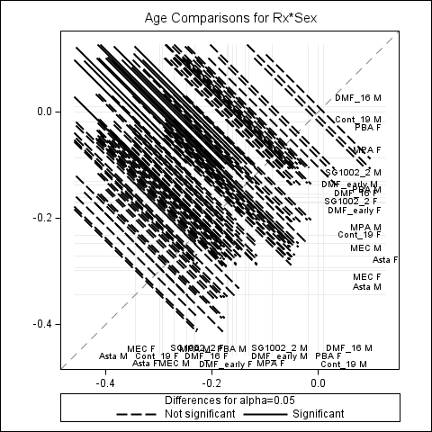

```
/* then below to fit the frailty model with a gamma distribution */

PROC PHREG data = ITP_data ;

   class Rx(ref="Cont_19") Sex Cage_site Site / param=glm;

   model Age*Dead(0) = Rx|Sex /;

   random Cage_site / dist = GAMMA;

   lsmeans Rx * Sex / means exp ODDSRATIO diff;

RUN;
```

| Model Information |  |  |
| --- | --- | --- |
| Data Set | WORK.ITP_DATA |  |
| Dependent Variable | Age | Age |
| Censoring Variable | Dead | Dead |
| Censoring Value(s) | 0 |  |
| Ties Handling | BRESLOW |  |
| Frailty | GAMMA |  |

| Number of Observations Read |
| --- |
| Number of Observations Used |

| 2635 |
| --- |
| 2635 |

| Class Level Information Class | Class Level Information Value | Class Level Information Design Variables | Class Level Information Design Variables | Class Level Information Design Variables | Class Level Information Design Variables | Class Level Information Design Variables | Class Level Information Design Variables | Class Level Information Design Variables | Class Level Information Design Variables |
| --- | --- | --- | --- | --- | --- | --- | --- | --- | --- |
| Rx | Asta | 1 | 0 | 0 | 0 | 0 | 0 | 0 | 0 |
|  | DMF_16 | 0 | 1 | 0 | 0 | 0 | 0 | 0 | 0 |
|  | DMF_early | 0 | 0 | 1 | 0 | 0 | 0 | 0 | 0 |
|  | MEC | 0 | 0 | 0 | 1 | 0 | 0 | 0 | 0 |
|  | MPA | 0 | 0 | 0 | 0 | 1 | 0 | 0 | 0 |
|  | PBA | 0 | 0 | 0 | 0 | 0 | 1 | 0 | 0 |
|  | SG1002_2 | 0 | 0 | 0 | 0 | 0 | 0 | 1 | 0 |
|  | Cont_19 | 0 | 0 | 0 | 0 | 0 | 0 | 0 | 1 |
| Sex | F | 1 | 0 |  |  |  |  |  |  |
|  | M | 0 | 1 |  |  |  |  |  |  |

| Class Level Information for Random Effects Class | Class Level Information for Random Effects Levels | Class Level Information for Random Effects Values |
| --- | --- | --- |
| Cage_site | 777 | 3300TJL 3301TJL 3302TJL 3303TJL 3304TJL 3305TJL 3306TJL 3307TJL 3308TJL 3309TJL 3310TJL 3311TJL 3312TJL 3313TJL 3314TJL 3315TJL 3316TJL 3317TJL 3318TJL 3319TJL 3320TJL 3321TJL 3322TJL 3323TJL 3324TJL … |

| Summary of the Number of Event and Censored Values Total | Summary of the Number of Event and Censored Values Event | Summary of the Number of Event and Censored Values Censored | Summary of the Number of Event and Censored Values Percent Censored |
| --- | --- | --- | --- |
| 2635 | 2569 | 66 | 2.50 |

| Convergence Status |
| --- |
| Convergence criterion (PCONV=0.0001) satisfied. |

| Marginal Loglikelihood | -20162.6 |
| --- | --- |

| Testing Global Null Hypothesis Test | Testing Global Null Hypothesis Chi-Square | Testing Global Null Hypothesis Adjusted DF | Testing Global Null Hypothesis Pr > ChiSq |
| --- | --- | --- | --- |
| Likelihood Ratio | 422.5305 | 183.04 | <.0001 |
| Wald | 236.6825 | 183.04 | 0.0046 |

| Covariance Parameter Estimates Cov Parm | Covariance Parameter Estimates Estimate |
| --- | --- |
| Cage_site | 0.08729 |

| Type 3 Tests Effect | Type 3 Tests Wald Chi-Square | Type 3 Tests DF | Type 3 Tests Pr > ChiSq | Type 3 Tests Adjusted DF | Type 3 Tests Adjusted Pr > ChiSq |
| --- | --- | --- | --- | --- | --- |
| Rx | 14.7734 | 7 | 0.0390 | 5.1485 | 0.0126 |
| Sex | 1.4850 | 1 | 0.2230 | 0.7415 | 0.1584 |
| Rx*Sex | 8.3350 | 7 | 0.3040 | 5.1490 | 0.1490 |
| Cage_site | 205.8143 | . | . | 168.04 | 0.0250 |

| Analysis of Maximum Likelihood Estimates Parameter | Analysis of Maximum Likelihood Estimates | Analysis of Maximum Likelihood Estimates | Analysis of Maximum Likelihood Estimates DF | Analysis of Maximum Likelihood Estimates Parameter Estimate | Analysis of Maximum Likelihood Estimates Standard Error | Analysis of Maximum Likelihood Estimates Chi-Square | Analysis of Maximum Likelihood Estimates Pr > ChiSq | Analysis of Maximum Likelihood Estimates Hazard Ratio | Analysis of Maximum Likelihood Estimates Label |
| --- | --- | --- | --- | --- | --- | --- | --- | --- | --- |
| Rx | Asta |  | 1 | -0.37794 | 0.11500 | 10.8004 | 0.0010 | . | Rx Asta |
| Rx | DMF_16 |  | 1 | 0.01113 | 0.11724 | 0.0090 | 0.9244 | . | Rx DMF_16 |
| Rx | DMF_early |  | 1 | -0.13794 | 0.11739 | 1.3808 | 0.2400 | . | Rx DMF_early |
| Rx | MEC |  | 1 | -0.28331 | 0.11739 | 5.8249 | 0.0158 | . | Rx MEC |
| Rx | MPA |  | 1 | -0.22207 | 0.11834 | 3.5217 | 0.0606 | . | Rx MPA |
| Rx | PBA |  | 1 | -0.13749 | 0.11743 | 1.3709 | 0.2417 | . | Rx PBA |
| Rx | SG1002_2 |  | 1 | -0.08983 | 0.11926 | 0.5673 | 0.4513 | . | Rx SG1002_2 |
| Rx | Cont_19 |  | 0 | 0 | . | . | . | . | Rx Cont_19 |
| Sex | F |  | 1 | -0.27222 | 0.09801 | 7.7146 | 0.0055 | . | Sex F |
| Sex | M |  | 0 | 0 | . | . | . | . | Sex M |
| Rx*Sex | Asta | F | 1 | 0.31147 | 0.16975 | 3.3668 | 0.0665 | . | Rx Asta * Sex F |
| Rx*Sex | Asta | M | 0 | 0 | . | . | . | . | Rx Asta * Sex M |
| Rx*Sex | DMF_16 | F | 1 | 0.08613 | 0.17098 | 0.2537 | 0.6145 | . | Rx DMF_16 * Sex F |
| Rx*Sex | DMF_16 | M | 0 | 0 | . | . | . | . | Rx DMF_16 * Sex M |
| Rx*Sex | DMF_early | F | 1 | 0.22146 | 0.17150 | 1.6675 | 0.1966 | . | Rx DMF_early * Sex F |
| Rx*Sex | DMF_early | M | 0 | 0 | . | . | . | . | Rx DMF_early * Sex M |
| Rx*Sex | MEC | F | 1 | 0.20778 | 0.17037 | 1.4874 | 0.2226 | . | Rx MEC * Sex F |
| Rx*Sex | MEC | M | 0 | 0 | . | . | . | . | Rx MEC * Sex M |
| Rx*Sex | MPA | F | 1 | 0.37754 | 0.17190 | 4.8236 | 0.0281 | . | Rx MPA * Sex F |
| Rx*Sex | MPA | M | 0 | 0 | . | . | . | . | Rx MPA * Sex M |
| Rx*Sex | PBA | F | 1 | 0.35286 | 0.17053 | 4.2813 | 0.0385 | . | Rx PBA * Sex F |
| Rx*Sex | PBA | M | 0 | 0 | . | . | . | . | Rx PBA * Sex M |
| Rx*Sex | SG1002_2 | F | 1 | 0.14987 | 0.17237 | 0.7559 | 0.3846 | . | Rx SG1002_2 * Sex F |
| Rx*Sex | SG1002_2 | M | 0 | 0 | . | . | . | . | Rx SG1002_2 * Sex M |
| Rx*Sex | Cont_19 | F | 0 | 0 | . | . | . | . | Rx Cont_19 * Sex F |
| Rx*Sex | Cont_19 | M | 0 | 0 | . | . | . | . | Rx Cont_19 * Sex M |

| Rx*Sex Least Squares Means Rx | Rx*Sex Least Squares Means Sex | Rx*Sex Least Squares Means Estimate | Rx*Sex Least Squares Means Standard Error | Rx*Sex Least Squares Means z Value | Rx*Sex Least Squares Means Pr > \|z\| | Rx*Sex Least Squares Means Exponentiated |
| --- | --- | --- | --- | --- | --- | --- |
| Asta | F | -0.3387 | 0.1232 | -2.75 | 0.0060 | 0.7127 |
| Asta | M | -0.3779 | 0.1150 | -3.29 | 0.0010 | 0.6853 |
| DMF_16 | F | -0.1750 | 0.1227 | -1.43 | 0.1540 | 0.8395 |
| DMF_16 | M | 0.01113 | 0.1172 | 0.09 | 0.9244 | 1.0112 |
| DMF_early | F | -0.1887 | 0.1233 | -1.53 | 0.1259 | 0.8280 |
| DMF_early | M | -0.1379 | 0.1174 | -1.18 | 0.2400 | 0.8711 |
| MEC | F | -0.3477 | 0.1218 | -2.86 | 0.0043 | 0.7063 |
| MEC | M | -0.2833 | 0.1174 | -2.41 | 0.0158 | 0.7533 |
| MPA | F | -0.1168 | 0.1229 | -0.95 | 0.3420 | 0.8898 |
| MPA | M | -0.2221 | 0.1183 | -1.88 | 0.0606 | 0.8009 |
| PBA | F | -0.05685 | 0.1219 | -0.47 | 0.6409 | 0.9447 |
| PBA | M | -0.1375 | 0.1174 | -1.17 | 0.2417 | 0.8715 |
| SG1002_2 | F | -0.2122 | 0.1227 | -1.73 | 0.0837 | 0.8088 |
| SG1002_2 | M | -0.08983 | 0.1193 | -0.75 | 0.4513 | 0.9141 |
| Cont_19 | F | -0.2722 | 0.09801 | -2.78 | 0.0055 | 0.7617 |
| Cont_19 | M | 0 | 0 | . | . | 1.0000 |

| Differences of Rx*Sex Least Squares Means Rx | Differences of Rx*Sex Least Squares Means Sex | Differences of Rx*Sex Least Squares Means Rx | Differences of Rx*Sex Least Squares Means Sex | Differences of Rx*Sex Least Squares Means Estimate | Differences of Rx*Sex Least Squares Means Standard Error | Differences of Rx*Sex Least Squares Means z Value | Differences of Rx*Sex Least Squares Means Pr > \|z\| | Differences of Rx*Sex Least Squares Means Exponentiated |
| --- | --- | --- | --- | --- | --- | --- | --- | --- |
| Asta | F | Asta | M | 0.03926 | 0.1387 | 0.28 | 0.7771 | 1.0400 |
| Asta | F | DMF_16 | F | -0.1637 | 0.1451 | -1.13 | 0.2592 | 0.8490 |
| Asta | F | DMF_16 | M | -0.3498 | 0.1405 | -2.49 | 0.0128 | 0.7048 |
| Asta | F | DMF_early | F | -0.1500 | 0.1455 | -1.03 | 0.3028 | 0.8607 |
| Asta | F | DMF_early | M | -0.2007 | 0.1407 | -1.43 | 0.1537 | 0.8181 |
| Asta | F | MEC | F | 0.009069 | 0.1442 | 0.06 | 0.9499 | 1.0091 |
| Asta | F | MEC | M | -0.05537 | 0.1407 | -0.39 | 0.6939 | 0.9461 |
| Asta | F | MPA | F | -0.2219 | 0.1452 | -1.53 | 0.1265 | 0.8010 |
| Asta | F | MPA | M | -0.1166 | 0.1416 | -0.82 | 0.4102 | 0.8899 |
| Asta | F | PBA | F | -0.2818 | 0.1444 | -1.95 | 0.0509 | 0.7544 |
| Asta | F | PBA | M | -0.2012 | 0.1408 | -1.43 | 0.1530 | 0.8178 |
| Asta | F | SG1002_2 | F | -0.1265 | 0.1450 | -0.87 | 0.3831 | 0.8812 |
| Asta | F | SG1002_2 | M | -0.2489 | 0.1424 | -1.75 | 0.0806 | 0.7797 |
| Asta | F | Cont_19 | F | -0.06646 | 0.1249 | -0.53 | 0.5946 | 0.9357 |
| Asta | F | Cont_19 | M | -0.3387 | 0.1232 | -2.75 | 0.0060 | 0.7127 |
| Asta | M | DMF_16 | F | -0.2030 | 0.1384 | -1.47 | 0.1425 | 0.8163 |
| Asta | M | DMF_16 | M | -0.3891 | 0.1335 | -2.91 | 0.0036 | 0.6777 |
| Asta | M | DMF_early | F | -0.1892 | 0.1388 | -1.36 | 0.1729 | 0.8276 |
| Asta | M | DMF_early | M | -0.2400 | 0.1335 | -1.80 | 0.0723 | 0.7866 |
| Asta | M | MEC | F | -0.03019 | 0.1375 | -0.22 | 0.8262 | 0.9703 |
| Asta | M | MEC | M | -0.09463 | 0.1335 | -0.71 | 0.4784 | 0.9097 |
| Asta | M | MPA | F | -0.2612 | 0.1386 | -1.88 | 0.0594 | 0.7701 |
| Asta | M | MPA | M | -0.1559 | 0.1343 | -1.16 | 0.2459 | 0.8557 |
| Asta | M | PBA | F | -0.3211 | 0.1377 | -2.33 | 0.0197 | 0.7254 |
| Asta | M | PBA | M | -0.2404 | 0.1336 | -1.80 | 0.0719 | 0.7863 |
| Asta | M | SG1002_2 | F | -0.1658 | 0.1383 | -1.20 | 0.2307 | 0.8473 |
| Asta | M | SG1002_2 | M | -0.2881 | 0.1352 | -2.13 | 0.0331 | 0.7497 |
| Asta | M | Cont_19 | F | -0.1057 | 0.1170 | -0.90 | 0.3660 | 0.8997 |
| Asta | M | Cont_19 | M | -0.3779 | 0.1150 | -3.29 | 0.0010 | 0.6853 |
| DMF_16 | F | DMF_16 | M | -0.1861 | 0.1401 | -1.33 | 0.1842 | 0.8302 |

[output cut: 90 more lines]

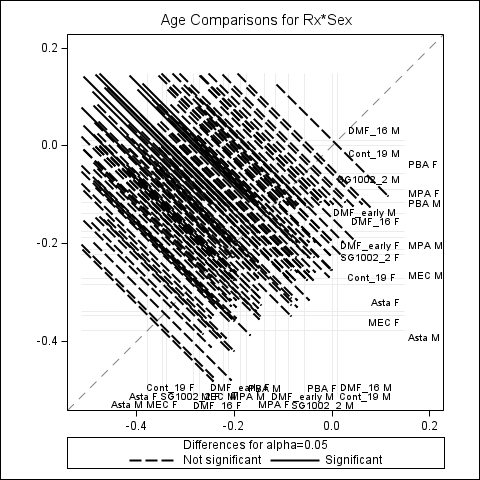

```
/* finally, below to fit the frailty model with a gaussian (lognormal) distribution */

PROC PHREG data = ITP_data;

   class Rx(ref="Cont_19") Sex Cage_site Site / param=glm;

   model Age*Dead(0) = Rx|Sex /;

   random Cage_site / dist = LOGNORMAL;

   lsmeans Rx * Sex / means exp ODDSRATIO diff;

RUN;
```

| Model Information |  |  |
| --- | --- | --- |
| Data Set | WORK.ITP_DATA |  |
| Dependent Variable | Age | Age |
| Censoring Variable | Dead | Dead |
| Censoring Value(s) | 0 |  |
| Ties Handling | BRESLOW |  |
| Frailty | LOGNORMAL |  |

| Number of Observations Read |
| --- |
| Number of Observations Used |

| 2635 |
| --- |
| 2635 |

| Class Level Information Class | Class Level Information Value | Class Level Information Design Variables | Class Level Information Design Variables | Class Level Information Design Variables | Class Level Information Design Variables | Class Level Information Design Variables | Class Level Information Design Variables | Class Level Information Design Variables | Class Level Information Design Variables |
| --- | --- | --- | --- | --- | --- | --- | --- | --- | --- |
| Rx | Asta | 1 | 0 | 0 | 0 | 0 | 0 | 0 | 0 |
|  | DMF_16 | 0 | 1 | 0 | 0 | 0 | 0 | 0 | 0 |
|  | DMF_early | 0 | 0 | 1 | 0 | 0 | 0 | 0 | 0 |
|  | MEC | 0 | 0 | 0 | 1 | 0 | 0 | 0 | 0 |
|  | MPA | 0 | 0 | 0 | 0 | 1 | 0 | 0 | 0 |
|  | PBA | 0 | 0 | 0 | 0 | 0 | 1 | 0 | 0 |
|  | SG1002_2 | 0 | 0 | 0 | 0 | 0 | 0 | 1 | 0 |
|  | Cont_19 | 0 | 0 | 0 | 0 | 0 | 0 | 0 | 1 |
| Sex | F | 1 | 0 |  |  |  |  |  |  |
|  | M | 0 | 1 |  |  |  |  |  |  |

| Class Level Information for Random Effects Class | Class Level Information for Random Effects Levels | Class Level Information for Random Effects Values |
| --- | --- | --- |
| Cage_site | 777 | 3300TJL 3301TJL 3302TJL 3303TJL 3304TJL 3305TJL 3306TJL 3307TJL 3308TJL 3309TJL 3310TJL 3311TJL 3312TJL 3313TJL 3314TJL 3315TJL 3316TJL 3317TJL 3318TJL 3319TJL 3320TJL 3321TJL 3322TJL 3323TJL 3324TJL … |

| Summary of the Number of Event and Censored Values Total | Summary of the Number of Event and Censored Values Event | Summary of the Number of Event and Censored Values Censored | Summary of the Number of Event and Censored Values Percent Censored |
| --- | --- | --- | --- |
| 2635 | 2569 | 66 | 2.50 |

| Convergence Status |
| --- |
| Convergence criterion (PCONV=0.0001) satisfied. |

| Marginal Loglikelihood | -17593.8 |
| --- | --- |

| Testing Global Null Hypothesis Test | Testing Global Null Hypothesis Chi-Square | Testing Global Null Hypothesis Adjusted DF | Testing Global Null Hypothesis Pr > ChiSq |
| --- | --- | --- | --- |
| Likelihood Ratio | 504.8979 | 220.57 | <.0001 |
| Wald | 297.7395 | 220.57 | 0.0004 |

| Covariance Parameter Estimates Cov Parm | Covariance Parameter Estimates REML Estimate | Covariance Parameter Estimates Standard Error |
| --- | --- | --- |
| Cage_site | 0.1210 | 0.02146 |

| Type 3 Tests Effect | Type 3 Tests Wald Chi-Square | Type 3 Tests DF | Type 3 Tests Pr > ChiSq | Type 3 Tests Adjusted DF | Type 3 Tests Adjusted Pr > ChiSq |
| --- | --- | --- | --- | --- | --- |
| Rx | 13.8530 | 7 | 0.0539 | 4.8053 | 0.0145 |
| Sex | 1.5268 | 1 | 0.2166 | 0.6924 | 0.1419 |
| Rx*Sex | 8.1029 | 7 | 0.3236 | 4.8057 | 0.1370 |
| Cage_site | 266.9549 | . | . | 205.57 | 0.0025 |

| Analysis of Maximum Likelihood Estimates Parameter | Analysis of Maximum Likelihood Estimates | Analysis of Maximum Likelihood Estimates | Analysis of Maximum Likelihood Estimates DF | Analysis of Maximum Likelihood Estimates Parameter Estimate | Analysis of Maximum Likelihood Estimates Standard Error | Analysis of Maximum Likelihood Estimates Chi-Square | Analysis of Maximum Likelihood Estimates Pr > ChiSq | Analysis of Maximum Likelihood Estimates Hazard Ratio | Analysis of Maximum Likelihood Estimates Label |
| --- | --- | --- | --- | --- | --- | --- | --- | --- | --- |
| Rx | Asta |  | 1 | -0.38019 | 0.11813 | 10.3579 | 0.0013 | . | Rx Asta |
| Rx | DMF_16 |  | 1 | 0.01300 | 0.12034 | 0.0117 | 0.9140 | . | Rx DMF_16 |
| Rx | DMF_early |  | 1 | -0.13714 | 0.12030 | 1.2996 | 0.2543 | . | Rx DMF_early |
| Rx | MEC |  | 1 | -0.28268 | 0.12045 | 5.5082 | 0.0189 | . | Rx MEC |
| Rx | MPA |  | 1 | -0.22145 | 0.12100 | 3.3492 | 0.0672 | . | Rx MPA |
| Rx | PBA |  | 1 | -0.14134 | 0.11998 | 1.3879 | 0.2388 | . | Rx PBA |
| Rx | SG1002_2 |  | 1 | -0.09184 | 0.12156 | 0.5708 | 0.4499 | . | Rx SG1002_2 |
| Rx | Cont_19 |  | 0 | 0 | . | . | . | . | Rx Cont_19 |
| Sex | F |  | 1 | -0.27747 | 0.10106 | 7.5386 | 0.0060 | . | Sex F |
| Sex | M |  | 0 | 0 | . | . | . | . | Sex M |
| Rx*Sex | Asta | F | 1 | 0.31626 | 0.17549 | 3.2477 | 0.0715 | . | Rx Asta * Sex F |
| Rx*Sex | Asta | M | 0 | 0 | . | . | . | . | Rx Asta * Sex M |
| Rx*Sex | DMF_16 | F | 1 | 0.08422 | 0.17647 | 0.2278 | 0.6332 | . | Rx DMF_16 * Sex F |
| Rx*Sex | DMF_16 | M | 0 | 0 | . | . | . | . | Rx DMF_16 * Sex M |
| Rx*Sex | DMF_early | F | 1 | 0.22465 | 0.17677 | 1.6150 | 0.2038 | . | Rx DMF_early * Sex F |
| Rx*Sex | DMF_early | M | 0 | 0 | . | . | . | . | Rx DMF_early * Sex M |
| Rx*Sex | MEC | F | 1 | 0.20709 | 0.17604 | 1.3839 | 0.2394 | . | Rx MEC * Sex F |
| Rx*Sex | MEC | M | 0 | 0 | . | . | . | . | Rx MEC * Sex M |
| Rx*Sex | MPA | F | 1 | 0.38139 | 0.17721 | 4.6321 | 0.0314 | . | Rx MPA * Sex F |
| Rx*Sex | MPA | M | 0 | 0 | . | . | . | . | Rx MPA * Sex M |
| Rx*Sex | PBA | F | 1 | 0.36082 | 0.17593 | 4.2064 | 0.0403 | . | Rx PBA * Sex F |
| Rx*Sex | PBA | M | 0 | 0 | . | . | . | . | Rx PBA * Sex M |
| Rx*Sex | SG1002_2 | F | 1 | 0.15285 | 0.17747 | 0.7418 | 0.3891 | . | Rx SG1002_2 * Sex F |
| Rx*Sex | SG1002_2 | M | 0 | 0 | . | . | . | . | Rx SG1002_2 * Sex M |
| Rx*Sex | Cont_19 | F | 0 | 0 | . | . | . | . | Rx Cont_19 * Sex F |
| Rx*Sex | Cont_19 | M | 0 | 0 | . | . | . | . | Rx Cont_19 * Sex M |

| Rx*Sex Least Squares Means Rx | Rx*Sex Least Squares Means Sex | Rx*Sex Least Squares Means Estimate | Rx*Sex Least Squares Means Standard Error | Rx*Sex Least Squares Means z Value | Rx*Sex Least Squares Means Pr > \|z\| | Rx*Sex Least Squares Means Exponentiated |
| --- | --- | --- | --- | --- | --- | --- |
| Asta | F | -0.3414 | 0.1276 | -2.67 | 0.0075 | 0.7108 |
| Asta | M | -0.3802 | 0.1181 | -3.22 | 0.0013 | 0.6837 |
| DMF_16 | F | -0.1802 | 0.1269 | -1.42 | 0.1554 | 0.8351 |
| DMF_16 | M | 0.01300 | 0.1203 | 0.11 | 0.9140 | 1.0131 |
| DMF_early | F | -0.1900 | 0.1273 | -1.49 | 0.1358 | 0.8270 |
| DMF_early | M | -0.1371 | 0.1203 | -1.14 | 0.2543 | 0.8719 |
| MEC | F | -0.3531 | 0.1262 | -2.80 | 0.0052 | 0.7025 |
| MEC | M | -0.2827 | 0.1204 | -2.35 | 0.0189 | 0.7538 |
| MPA | F | -0.1175 | 0.1272 | -0.92 | 0.3555 | 0.8891 |
| MPA | M | -0.2214 | 0.1210 | -1.83 | 0.0672 | 0.8014 |
| PBA | F | -0.05799 | 0.1264 | -0.46 | 0.6464 | 0.9437 |
| PBA | M | -0.1413 | 0.1200 | -1.18 | 0.2388 | 0.8682 |
| SG1002_2 | F | -0.2165 | 0.1271 | -1.70 | 0.0884 | 0.8054 |
| SG1002_2 | M | -0.09184 | 0.1216 | -0.76 | 0.4499 | 0.9122 |
| Cont_19 | F | -0.2775 | 0.1011 | -2.75 | 0.0060 | 0.7577 |
| Cont_19 | M | 0 | 0 | . | . | 1.0000 |

| Differences of Rx*Sex Least Squares Means Rx | Differences of Rx*Sex Least Squares Means Sex | Differences of Rx*Sex Least Squares Means Rx | Differences of Rx*Sex Least Squares Means Sex | Differences of Rx*Sex Least Squares Means Estimate | Differences of Rx*Sex Least Squares Means Standard Error | Differences of Rx*Sex Least Squares Means z Value | Differences of Rx*Sex Least Squares Means Pr > \|z\| | Differences of Rx*Sex Least Squares Means Exponentiated |
| --- | --- | --- | --- | --- | --- | --- | --- | --- |
| Asta | F | Asta | M | 0.03879 | 0.1436 | 0.27 | 0.7870 | 1.0396 |
| Asta | F | DMF_16 | F | -0.1612 | 0.1508 | -1.07 | 0.2851 | 0.8512 |
| Asta | F | DMF_16 | M | -0.3544 | 0.1453 | -2.44 | 0.0148 | 0.7016 |
| Asta | F | DMF_early | F | -0.1514 | 0.1511 | -1.00 | 0.3163 | 0.8595 |
| Asta | F | DMF_early | M | -0.2043 | 0.1454 | -1.40 | 0.1601 | 0.8152 |
| Asta | F | MEC | F | 0.01166 | 0.1502 | 0.08 | 0.9381 | 1.0117 |
| Asta | F | MEC | M | -0.05872 | 0.1455 | -0.40 | 0.6865 | 0.9430 |
| Asta | F | MPA | F | -0.2239 | 0.1510 | -1.48 | 0.1383 | 0.7994 |
| Asta | F | MPA | M | -0.1199 | 0.1461 | -0.82 | 0.4115 | 0.8870 |
| Asta | F | PBA | F | -0.2834 | 0.1504 | -1.88 | 0.0595 | 0.7532 |
| Asta | F | PBA | M | -0.2001 | 0.1452 | -1.38 | 0.1682 | 0.8187 |
| Asta | F | SG1002_2 | F | -0.1249 | 0.1509 | -0.83 | 0.4077 | 0.8826 |
| Asta | F | SG1002_2 | M | -0.2496 | 0.1466 | -1.70 | 0.0887 | 0.7791 |
| Asta | F | Cont_19 | F | -0.06393 | 0.1298 | -0.49 | 0.6223 | 0.9381 |
| Asta | F | Cont_19 | M | -0.3414 | 0.1276 | -2.67 | 0.0075 | 0.7108 |
| Asta | M | DMF_16 | F | -0.1999 | 0.1430 | -1.40 | 0.1620 | 0.8188 |
| Asta | M | DMF_16 | M | -0.3932 | 0.1372 | -2.87 | 0.0042 | 0.6749 |
| Asta | M | DMF_early | F | -0.1902 | 0.1433 | -1.33 | 0.1844 | 0.8268 |
| Asta | M | DMF_early | M | -0.2431 | 0.1370 | -1.77 | 0.0761 | 0.7842 |
| Asta | M | MEC | F | -0.02713 | 0.1423 | -0.19 | 0.8488 | 0.9732 |
| Asta | M | MEC | M | -0.09751 | 0.1371 | -0.71 | 0.4770 | 0.9071 |
| Asta | M | MPA | F | -0.2627 | 0.1433 | -1.83 | 0.0668 | 0.7690 |
| Asta | M | MPA | M | -0.1587 | 0.1376 | -1.15 | 0.2488 | 0.8532 |
| Asta | M | PBA | F | -0.3222 | 0.1427 | -2.26 | 0.0239 | 0.7246 |
| Asta | M | PBA | M | -0.2388 | 0.1368 | -1.75 | 0.0808 | 0.7875 |
| Asta | M | SG1002_2 | F | -0.1637 | 0.1431 | -1.14 | 0.2526 | 0.8490 |
| Asta | M | SG1002_2 | M | -0.2883 | 0.1382 | -2.09 | 0.0370 | 0.7495 |
| Asta | M | Cont_19 | F | -0.1027 | 0.1206 | -0.85 | 0.3943 | 0.9024 |
| Asta | M | Cont_19 | M | -0.3802 | 0.1181 | -3.22 | 0.0013 | 0.6837 |
| DMF_16 | F | DMF_16 | M | -0.1932 | 0.1447 | -1.34 | 0.1817 | 0.8243 |

[output cut: 90 more lines]

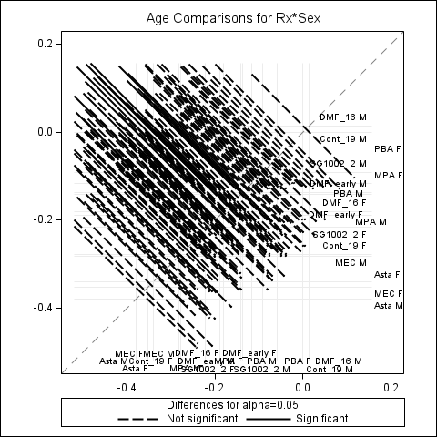

Back to top

# References

1.

Bell ML, Rabe BA. The mixed model for repeated measures for cluster randomized trials: A simulation study investigating bias and type i error with missing continuous data. Trials [Internet]. 2020 Feb 7;21(1). Available from: http://dx.doi.org/10.1186/s13063-020-4114-9

2.

Li P, Redden DT. Small sample performance of bias-corrected sandwich estimators for cluster-randomized trials with binary outcomes. Statistics in Medicine [Internet]. 2014 Oct 24;34(2):281–96. Available from: http://dx.doi.org/10.1002/sim.6344

3.

Murray DM, Varnell SP, Blitstein JL. Design and analysis of group-randomized trials: A review of recent methodological developments. American Journal of Public Health [Internet]. 2004 Mar;94(3):423–32. Available from: http://dx.doi.org/10.2105/ajph.94.3.423

4.

Chusyd DE, Austad SN, Dickinson SL, Ejima K, Gadbury GL, Golzarri-Arroyo L, et al. Randomization, design and analysis for interdependency in aging research: No person or mouse is an island. Nature Aging [Internet]. 2022 Dec 22;2(12):1101–11. Available from: http://dx.doi.org/10.1038/s43587-022-00333-6

5.

Golzarri-Arroyo L, Dickinson SL, Jamshidi-Naeini Y, Zoh RS, Brown AW, Owora AH, et al. Evaluation of the type i error rate when using parametric bootstrap analysis of a cluster randomized controlled trial with binary outcomes and a small number of clusters. Computer Methods and Programs in Biomedicine [Internet]. 2022 Mar;215:106654. Available from: http://dx.doi.org/10.1016/j.cmpb.2022.106654

6.

Jamshidi-Naeini Y, Brown AW, Mehta T, Glueck DH, Golzarri-Arroyo L, Muller KE, et al. A practical decision tree to support editorial adjudication of submitted parallel cluster randomized controlled trials. Obesity [Internet]. 2022 Feb 23;30(3):565–70. Available from: http://dx.doi.org/10.1002/oby.23373

7.

McDermott JJ, Schukken YH, Shoukri MM. Study design and analytic methods for data collected from clusters of animals. Preventive Veterinary Medicine [Internet]. 1994 Feb;18(3):175–91. Available from: http://dx.doi.org/10.1016/0167-5877(94)90074-4

8.

Leyrat C, Morgan KE, Leurent B, Kahan BC. Cluster randomized trials with a small number of clusters: Which analyses should be used? International Journal of Epidemiology [Internet]. 2018 Mar 27;47(3):1012–2. Available from: http://dx.doi.org/10.1093/ije/dyy057

9.

Li P, Redden DT. Comparing denominator degrees of freedom approximations for the generalized linear mixed model in analyzing binary outcome in small sample cluster-randomized trials. BMC Medical Research Methodology [Internet]. 2015 Apr 23;15(1). Available from: http://dx.doi.org/10.1186/s12874-015-0026-x

10.

Festing MFW, Altman DG. Guidelines for the design and statistical analysis of experiments using laboratory animals. ILAR Journal [Internet]. 2002 Jan 1;43(4):244–58. Available from: http://dx.doi.org/10.1093/ilar.43.4.244

11.

Brown AW, Li P, Bohan Brown MM, Kaiser KA, Keith SW, Oakes JM, et al. Best (but oft-forgotten) practices: Designing, analyzing, and reporting cluster randomized controlled trials. The American Journal of Clinical Nutrition [Internet]. 2015 Aug;102(2):241–8. Available from: http://dx.doi.org/10.3945/ajcn.114.105072

12.

Bates D, Mächler M, Bolker B, Walker S. Fitting linear mixed-effects models using**lme4**. Journal of Statistical Software [Internet]. 2015;67(1). Available from: http://dx.doi.org/10.18637/jss.v067.i01

13.

Kahan BC, Forbes G, Ali Y, Jairath V, Bremner S, Harhay MO, et al. Increased risk of type i errors in cluster randomised trials with small or medium numbers of clusters: A review, reanalysis, and simulation study. Trials [Internet]. 2016 Sept 6;17(1). Available from: http://dx.doi.org/10.1186/s13063-016-1571-2

14.

Parker ES, Golzarri-Arroyo L, Dickinson S, Henschel B, Becerra-Garcia LE, Mokalla TR, et al. Improving statistical rigor in animal aging research by addressing clustering and nesting effects: Illustration with the national institute on aging’s intervention testing program data [Internet]. 2025. Available from: http://dx.doi.org/10.1101/2025.03.14.642436

15.

Parker ES, Golzarri-Arroyo L, Dickinson S, Henschel B, Becerra-Garcia LE, Mokalla TR, et al. Improving statistical rigor in animal aging research by addressing clustering and nesting effects: Illustration with the national institute on aging’s intervention testing program data. Duque G, editor. The Journals of Gerontology, Series A: Biological Sciences and Medical Sciences [Internet]. 2026 Mar 15;81(5). Available from: http://dx.doi.org/10.1093/gerona/glag074

16.

Harrison DE, Strong R, Reifsnyder P, Rosenthal N, Korstanje R, Fernandez E, et al. Astaxanthin and meclizine extend lifespan in UM-HET3 male mice; fisetin, SG1002 (hydrogen sulfide donor), dimethyl fumarate, mycophenolic acid, and 4-phenylbutyrate do not significantly affect lifespan in either sex at the doses and schedules used. GeroScience [Internet]. 2023 Dec 2;46(1):795–816. Available from: http://dx.doi.org/10.1007/s11357-023-01011-0

17.

Shrout PE, Fleiss JL. Intraclass correlations: Uses in assessing rater reliability. Psychological Bulletin [Internet]. 1979;86(2):420–8. Available from: http://dx.doi.org/10.1037/0033-2909.86.2.420

18.

Balan TA, Putter H. A tutorial on frailty models. Statistical Methods in Medical Research [Internet]. 2020 May 28;29(11):3424–54. Available from: http://dx.doi.org/10.1177/0962280220921889

19.

Therneau TM, Grambsch PM. Modeling survival data: Extending the cox model [Internet]. Springer New York; 2000. Available from: http://dx.doi.org/10.1007/978-1-4757-3294-8